# Intentional Self-Harm Mortality

It’s a world wide suicide

Zackary Scalyer

April 28, 2019

# Input data

Google BigQuery with kaggle.com [Python type kernel](https://www.kaggle.com/zack0179/first-bigquery?scriptVersionId=13175739)

- [World Bank: Education Data](https://www.kaggle.com/theworldbank/world-bank-intl-education)

> This dataset combines key education statistics from a variety of sources to provide a look at global literacy, spending, and access
- [World Development Indicators](https://www.kaggle.com/bigquery/worldbank-wdi) (WDI)

> World Development Indicators Data is the primary World Bank collection of development indicators, compiled from officially-recognized international sources. It presents the most current and accurate global development data available, and includes national, regional and global estimates.

20 potential regressors where selected by indicator name, code, and value; 10 from World Bank Eduction and 10 from World Development Indicators.

World Health Organization (WHO) [Mortality Database](http://apps.who.int/healthinfo/statistics/mortality/whodpms/)

- Selected potential regressor, sucide counts, and exported data table with online tool.

  > ‘No. of deaths - Intentional self-harm’, for all countries from 1999 to 2016

Global Health Observatory [data repository](http://apps.who.int/gho/data/view.main.MHSUICIDEv?lang=en)

- Download complete data sets for each measure of sucide rate.

  > ‘Suicide mortality rate (per 100 000 population)’. Number of suicide deaths in a year, divided by the population and multiplied by 100 000.

World Health Statistics data visualizations [dashboard](http://apps.who.int/gho/data/node.sdg.3-4-data?lang=en)

- Download complete data set containing suicide rate and a measure of non-self-harm related mortality.

  > ‘Probability of dying between exact ages 30 and 70 from any of cardiovascular disease, cancer, diabetes, or chronic respiratory disease.’. Percent of 30-year-old-people who would die before their 70th birthday from any of cardiovascular disease, cancer, diabetes, or chronic respiratory disease, assuming that s/he would experience current mortality rates at every age and s/he would not die from any other cause of death (e.g., injuries or HIV/AIDS).

  > ‘Suicide mortality rate (per 100 000 population)’. Number of suicide deaths in a year, divided by the population and multiplied by 100 000.
  - Observed units of country by sex for 2016, 2015, 2010, 2005, and 2000.

```r
# function for recoding country to common names and droping non-countries
funContry <- function(dat){
  return(dat %>%
           mutate(country = recode(country,
                                   "United States"= "USA",  "United States of America"="USA",
                                   "Bolivia (Plurinational State of)" = "Bolivia",
                                   "Virgin Islands (U.S.)" = "Virgin Islands (USA)",
                                   "Brunei Darussalam" = "Brunei",
                                   "Cabo Verde" = "Cape Verde",
                                   "Congo" = "Republic of Congo", "Congo, Rep." = "Republic of Congo",
                                   "Congo, Dem. Rep." = "Democratic Republic of the Congo",
                                   "Côte d'Ivoire" = "Cote d'Ivoire",
                                   "Czechia" = "Czech Republic",
                                  "Democratic People's Republic of Korea" = "North Korea",
                                  "Korea, Dem. People’s Rep." = "North Korea",
                                  "Korea, Dem. People<U+FFFD>s Rep." = "North Korea",
                                  "Republic of Korea" = "South Korea", "Korea, Rep." = "South Korea",
                                  "Egypt, Arab Rep." = "Egypt",
                                  "Eswatini" = "Swaziland",
                                  "Gambia, The" = "Gambia",
                                  "Hong Kong SAR, China" = "Hong Kong SAR",
                                  "Iran, Islamic Rep." = "Iran", "Iran (Islamic Rep of)" = "Iran",
                                  "Iran (Islamic Republic of)" = "Iran",
                                  "Lao PDR" = "Laos", "Lao People's Democratic Republic" = "Laos",
                                  "Macedonia, FYR" = "Macedonia", "TFYR Macedonia" = "Macedonia",
                                  "Republic of North Macedonia"="Macedonia",
                                  "Micronesia, Fed. Sts." = "Micronesia",
                                  "Micronesia (Federated States of)" = "Micronesia",
                                  "Republic of Moldova" = "Moldova", "Russian Federation" = "Russia",
                                  "St. Kitts and Nevis" = "Saint Kitts and Nevis",
                                  "Saint Vincent and the Grenadines" = "Saint Vincent and Grenadines",
                                  "St. Vincent and the Grenadines" = "Saint Vincent and Grenadines",
                                  "St. Lucia" = "Saint Lucia",
                                  "Syrian Arab Republic" = "Syria",
                                  "United Kingdom of Great Britain and Northern Ireland" = "UK",
                                  "United Kingdom" = "UK",
                                  "United Republic of Tanzania" = "Tanzania",
                                  "Venezuela (Bolivarian Republic of)" = "Venezuela",
                                  "Venezuela, RB" = "Venezuela",
                                  "Viet Nam" = "Vietnam",
                                  "Yemen, Rep." = "Yemen")) %>%
           filter(!country %in%  c("Arab World", "Caribbean small states", "Central Europe and the Baltics",
                                   "Channel Islands", "Cote d'Ivoire", "Early-demographic dividend",
                                   "East Asia & Pacific", "East Asia & Pacific (excluding high income)",
                                   "East Asia & Pacific (IDA & IBRD countries)",
                                   "Euro area", "Europe & Central Asia",
                                   "Europe & Central Asia (excluding high income)",
                                   "Europe & Central Asia (IDA & IBRD countries)", "European Union",
                                   "Fragile and conflict affected situations", "Gibraltar",
                                   "Heavily indebted poor countries (HIPC)",
                                   "High income", "IBRD only", "IDA & IBRD total", "IDA blend", "IDA only",
                                   "IDA total", "Late-demographic dividend", "Latin America & Caribbean",
                                   "Latin America & Caribbean (excluding high income)",
                                   "Latin America & the Caribbean (IDA & IBRD countries)",
                                   "Least developed countries: UN classification", "Low & middle income",
                                   "Low income", "Lower middle income", "Macao SAR, China",
                                   "Middle East & North Africa",
                                   "Middle East & North Africa (excluding high income)",
                                   "Middle East & North Africa (IDA & IBRD countries)", "Middle income",
                                   "Netherlands Antilles", "North America", "Not classified",
                                   "Occupied Palestinian Territory", "OECD members", "Other small states",
                                   "Pacific island small states", "Post-demographic dividend",
                                   "Pre-demographic dividend", "Rodrigues", "Sint Maarten (Dutch part)",
                                   "Small states", "South Asia", "South Asia (IDA & IBRD)",
                                   "St. Martin (French part)", "Sub-Saharan Africa",
                                   "Sub-Saharan Africa (excluding high income)",
                                   "Sub-Saharan Africa (IDA & IBRD countries)", "Tuvalu",
                                   "Upper middle income", "West Bank and Gaza", "World"))
  )
}

# fun for listing contrys' that mached|unmached to a region in worldMap
checkingCountry <- function(full_dat, worldMap){
  require(dplyr)
  return(list(
    nomatch = unique(full_dat$country[!(full_dat$country %in% unique(worldMap$region))]) %>%
               sort() %>%
               as.character(),
    match = unique(full_dat$country[(full_dat$country %in% unique(worldMap$region))]) %>%
               sort() %>%
               as.character()
    )
  )
}


## functions to help fit models with clean data in a genaric way
# given a data set, select only varables for a model
z.getModelDat <- function(dat, DV, IVs){
  return(dat %>% select(append(DV,IVs)) %>% drop_na())
}

# fit a model given data, responce as char, and regressiors as chars
z.getFit <- function(dat, DV, IVs, wts = NULL){
  return(dat %>%
           select(append(DV,IVs)) %>%
           drop_na() %>%
           lm(as.formula(paste(DV, '~',
                               paste0(IVs, collapse = '+'))),
              data = .,
              weights = wts)
         )
}

# function for nested stepwise model building
z.step <- function(dat,
                   DV = 'suicide_rate',
                   IVs = c("growth", "preprimary", "UnemployMale", "GDP", "dying")){
  mod_dat <- z.getModelDat(dat, DV, IVs)
  fit.null <- lm(as.formula(paste(DV, '~', '1')), data = mod_dat)
  fit.full <- lm(as.formula(paste(DV, '~', paste0(IVs, collapse = '+'))),
                 data = mod_dat)
  return(step(fit.null,
              scope = list(lower = fit.null, upper = fit.full),
              direction = c('forward')))
}

# function for ploting model coeffents with broom::tidy() resutls of fit
z.plotMargin_results <- function(fit_results, title = 'Marginal Coeffents'){
  return(fit_results %>%
           filter(term != '(Intercept)') %>%
           ggplot(., aes(x = term, y = estimate, color = term)) +
           geom_hline(yintercept = 0, color = "sienna", linetype="dashed") +
#           geom_point(aes(size=abs(statistic))) +
           geom_point() +
           geom_errorbar(aes(ymin = conf.low, ymax = conf.high), width = 0.2) +
           scale_color_discrete(guide=FALSE) +
           labs(title = title, x = NULL)  +
           theme(plot.title = element_text(hjust = 0.5)) +
           coord_flip()
         )
}

# functions for fitting weights
# varance method
wts.varfun <- function(fit){
  return(1/fitted(lm(residuals(fit)^2 ~ fitted(fit))))
}

# standrd deveation method
wts.sdfun <- function(fit){
  if (!any(fitted(lm(abs(residuals(fit)) ~ fitted(fit))) < 0)){
    return(1/fitted(lm(abs(residuals(fit)) ~ fitted(fit)))^2)
  } else{
    return(print('at least one wt < 0'))
  }
}

# puts both together
wtsfun <- function(fit){
  if (!any(wts.varfun(fit) < 0)){
    return(wts.varfun(fit))
  } else if (!any(fitted(lm(abs(residuals(fit)) ~ fitted(fit))) < 0)){
    return(wts.sdfun(fit))
  } else{
    return(print('weights can not be negitive'))
  }
}
```

```r
## Reading, Cleaning, and Merging Data
# home dir
fpath <- "C:/Users/zack0/Documents/School/Villanova/SP_2019/MAT_8406_Regression/Project/"

# data sets
WID_edu_BigQ <- read_csv(paste0(fpath,"WID_edu_merge.csv")) %>%
  filter(year %in% seq(2000,2015,by=5))
######## There is at least one error remaining in the data pertainging to North Korea.
# NOTE # - "Korea, Dem. People<U+FFFD>s Rep." = "North Korea"
######## - this is corrected after mergeing by; group, fill-up, and slice-first

tableA <- read_csv(paste0(fpath,"tablea.csv"),skip = 1)
WHO_CurdSuicidRate <- read_csv(paste0(fpath,"WHO_CurdSuicidRate.csv"),skip = 1)
WHO_AgeSuicidRate <- read_csv(paste0(fpath,"WHO_AgeSuicidRate.csv"),skip = 1)
WHS_CrudeSusideRate <- read_csv(paste0(fpath,"WorldHelthStatics_CrudeSusideRate.csv"),skip = 1)
# Kaggel data
WID_edu_BigQ$year <- as.character(WID_edu_BigQ$year)

# summary(WID_edu_BigQ)
# data structure in long format
```

```r
# World Helth Organizatio (WHO) Mortality Database
# - data structure is wide
tableA_long <- gather(tableA, year, suicide_count, 2:18, na.rm=TRUE) %>%
  filter(year %in% seq(2000,2015,5)) %>%
  rename("country" = "Countries")

# str(tableA_long)
# data structure in long format
```

```r
# WHO Global Health Observatory data repository
# - data structure is wide
WHO_suicid_rate <- WHO_CurdSuicidRate %>%
  gather( year, suicide_per100k, 3:7) %>%
  filter(Sex=="Both sexes") %>%
  rename("country" = "Country") %>%
  select(-Sex)

# str(WHO_suicid_rate)
# data structure in long format
```

```r
# WHO Global Health Observatory data repository
# - data structure is wide
WHO_suicid_agerate <- WHO_AgeSuicidRate %>%
  gather(year, suicide_ageadj, 3:6) %>%
  filter(Sex=="Both sexes") %>%
  rename("country" = "Country") %>%
  select(-Sex)

# str(WHO_suicid_agerate)
# data structure in long format: NOTE 2005 is missing
```

```r
# World Health Statistics data visualizations dashboard
# - data structure in long format
WHS_dat <- WHS_CrudeSusideRate %>%
  mutate(Probability_30to70_dying = get('Both sexes'),
         suicide_rate = get('Both sexes_1'),
         country = Country,
         year = as.character(Year)) %>%
  select(c(country, year, Probability_30to70_dying, suicide_rate))

# str(WHS_dat)
```

```r
# Cleaning contry names and droping non-contries obs
BigQclean <- funContry(WID_edu_BigQ)

tableAclean <- tableA_long %>%
  mutate_if(is.factor, as.character) %>%
  funContry()

rateClean <- funContry(WHO_suicid_rate)

agerateClean <- funContry(WHO_suicid_agerate)

WHSclean <- funContry(WHS_dat)
```

```r
# Merge data by country ans year
selfharm_dat <- WHSclean %>%
  left_join(BigQclean, by = c("country", "year")) %>%
  left_join(tableAclean, by = c("country", "year"))  %>%
  left_join(rateClean, by = c("country", "year"))  %>%
  left_join(agerateClean, by = c("country", "year")) %>%
  group_by(country, year) %>%
  fill(-c(country,year), .direction='up') %>%
  slice(1)  %>%
  ungroup() %>%
  mutate_if(is.character, factor)

# names(selfharm_dat)
```

```r
# data set for country latitude and longitude data.
worldMap <- map_data('world')

# update worldMap to match regions or subregions with conties
# - creating new region for subregions that match conties
worldMap_1 <- worldMap %>%
  filter(region == "Antigua" | region == "Barbuda" ) %>%
  select(-subregion) %>%
  rename(subregion = region) %>%
  mutate(region = "Antigua and Barbuda")

worldMap_2 <- worldMap %>%
  filter(region == "Virgin Islands", str_detect(subregion, "US")) %>%
  mutate(region = "Virgin Islands (USA)") # no self-harm data for British Virgin Islands

worldMap_3 <- worldMap %>%
  filter(region == "Virgin Islands", str_detect(subregion, "British")) %>%
  mutate(region = "British Virgin Islands") # no self-harm data for British Virgin Islands

worldMap_4 <- worldMap %>%
  filter(region == "China", subregion == "Hong Kong") %>%
  mutate(region = "Hong Kong SAR")

worldMap_5 <- worldMap %>%
  filter(region == "Saint Kitts") %>%
  select(-subregion) %>%
  rename(subregion = region) %>%
  mutate(region = "Saint Kitts and Nevis")

worldMap_6 <- worldMap %>%
  filter(region == "Nevis") %>%
  select(-subregion) %>%
  rename(subregion = region) %>%
  mutate(region = "Saint Kitts and Nevis")

worldMap_7 <- worldMap %>%
  filter(region == "Saint Vincent") %>%
  select(-subregion) %>%
  rename(subregion = region) %>%
  mutate(region = "Saint Vincent and Grenadines")

worldMap_8 <- worldMap %>%
  filter(region == "Grenadines") %>%
  select(-subregion) %>%
  rename(subregion = region) %>%
  mutate(region = "Saint Vincent and Grenadines")

worldMap_9 <- worldMap %>%
  filter(region == "Trinidad") %>%
  select(-subregion) %>%
  rename(subregion = region) %>%
  mutate(region = "Trinidad and Tobago")

worldMap_10 <- worldMap %>%
  filter(region == "Tobago") %>%
  select(-subregion) %>%
  rename(subregion = region) %>%
  mutate(region = "Trinidad and Tobago")

worldMap_selfharm <- worldMap %>%
  bind_rows(worldMap_1) %>%
  bind_rows(worldMap_2) %>%
  bind_rows(worldMap_3) %>%
  bind_rows(worldMap_4) %>%
  bind_rows(worldMap_5) %>%
  bind_rows(worldMap_6) %>%
  bind_rows(worldMap_7) %>%
  bind_rows(worldMap_8) %>%
  bind_rows(worldMap_9) %>%
  bind_rows(worldMap_10)

remove(worldMap_1, worldMap_2, worldMap_3, worldMap_4,
       worldMap_5, worldMap_6, worldMap_7, worldMap_8,
       worldMap_9, worldMap_10)
```

```r
# check
check_mached <- checkingCountry(selfharm_dat, worldMap_selfharm)
# unmached
check_mached$nomatch
#matched
check_mached$match
```

# Data exploration

```r
selfharm_2010 <- filter(selfharm_dat, year == 2010) %>%
  select(-c(population_total_edu, suicide_per100k, precipitation)) %>%
  rename(population = population_totl_WID)
```

## Responce varables

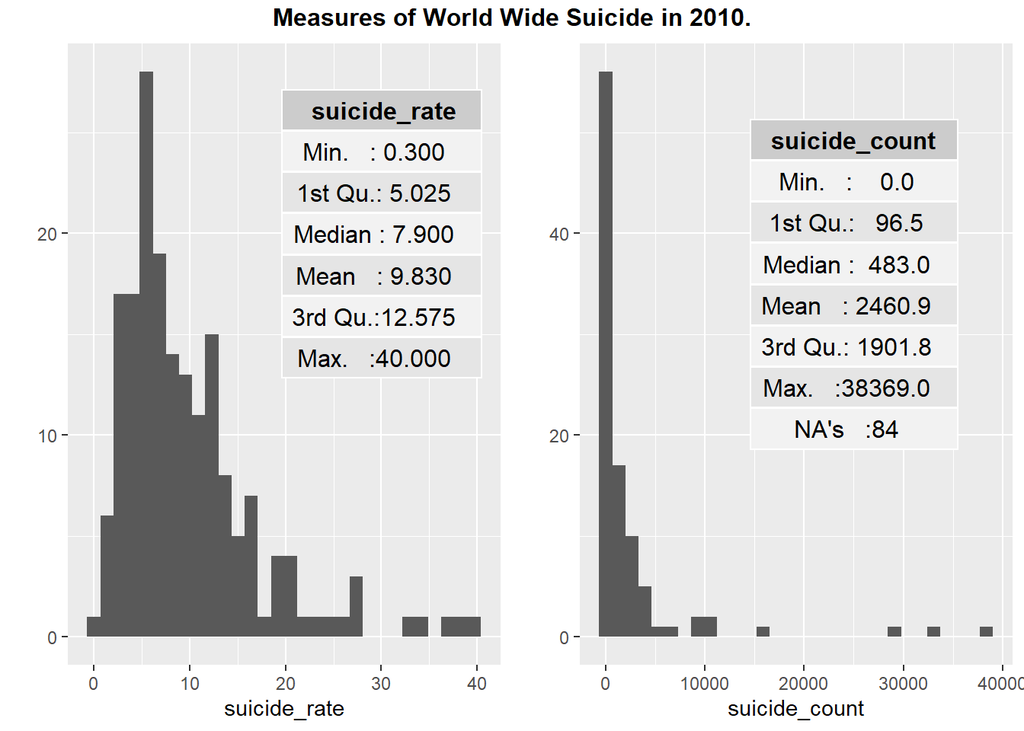

```r
selfharm_2010 %>%
  select(suicide_count) %>%
  summary() %>%
  cbind() %>% as.table() -> tc

selfharm_2010 %>%
  select(suicide_rate) %>%
  summary() %>%
  cbind() %>% as.table() -> tr

ax1 <- qplot(data=selfharm_2010, x=suicide_rate, geom='histogram', bins=30) +
  annotation_custom(tableGrob(tr, rows=NULL), xmin=20, xmax=40, ymin=10, ymax=30)


ax2 <- qplot(data=selfharm_2010, x=suicide_count, geom='histogram', bins=30) +
  annotation_custom(tableGrob(tc, rows=NULL), xmin=10000, xmax=40000, ymin=10, ymax=60)

grid.arrange(ax1,ax2,ncol = 2,
             top = textGrob('Measures of World Wide Suicide in 2010.',
                            gp=gpar(fontface = 'bold')))
```

```r
remove(tc,tr)
```

## Probability of dying

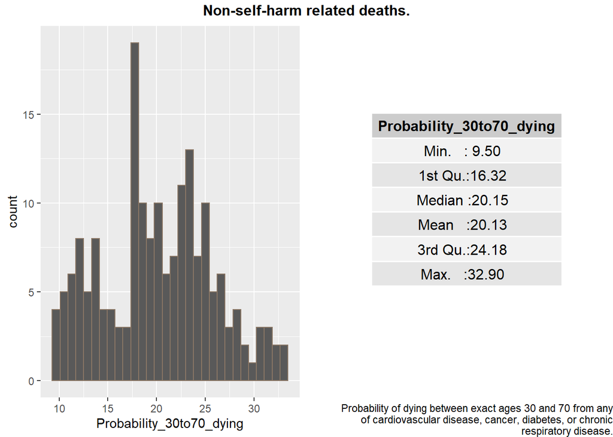

```r
selfharm_2010 %>%
  select(Probability_30to70_dying) %>%
  summary() %>%
  as.table() -> t

caption = 'Probability of dying between exact ages 30 and 70 from any of cardiovascular disease, cancer, diabetes, or chronic respiratory disease.'

ax1 <- ggplot(selfharm_2010, aes(Probability_30to70_dying)) +
  geom_histogram(bins = 30, color = 'peachpuff4')

ax2 <- ggplot(selfharm_2010, aes(Probability_30to70_dying)) +
  annotation_custom(tableGrob(t, rows=NULL),
                    xmin=0, xmax=Inf, ymin=0, ymax=Inf) +
  labs(caption = str_wrap(caption, width = 60)) +
  theme(plot.caption = element_text(hjust = 0)) +
  theme_void()

grid.arrange(ax1,
             ax2,
             ncol = 2,
             top = textGrob('Non-self-harm related deaths.',
                            gp=gpar(fontface = 'bold')))
```

```r
remove(t, caption)
```

## Population

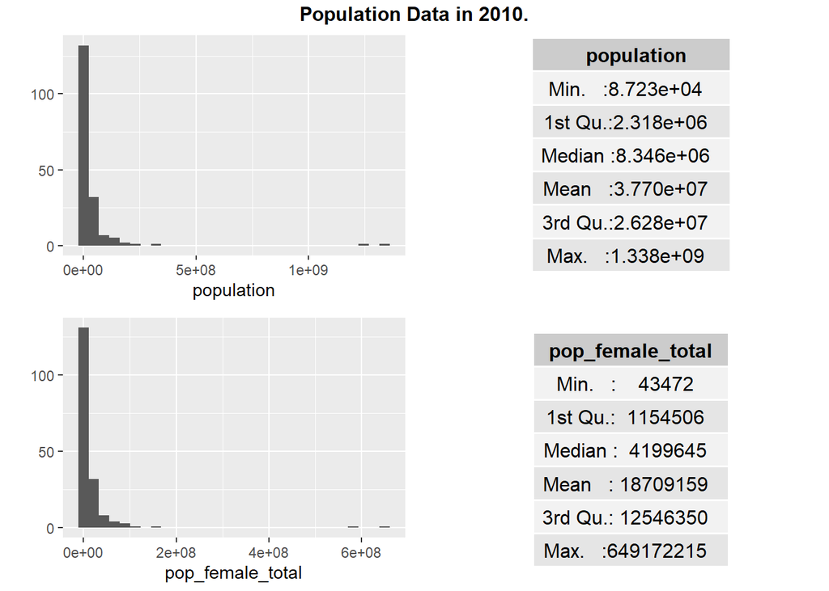

```r
selfharm_2010 %>%
  select(population) %>%
  summary() %>% as.table() -> t1
selfharm_2010 %>%
  select(pop_female_total) %>%
  summary() %>% as.table() -> t2

ax1 <- qplot(data=selfharm_2010, x=population, geom='histogram', bins = 30)
ax2 <- ggplot(selfharm_2010, aes(population)) +
  annotation_custom(tableGrob(t1, rows=NULL),
                    xmin=0, xmax=Inf, ymin=0.05, ymax=Inf) +
  theme(plot.caption = element_text(hjust = 0)) +
  theme_void()

ax3 <- qplot(data=selfharm_2010, x=pop_female_total, geom='histogram', bins = 30)
ax4 <- ggplot(selfharm_2010, aes(pop_female_total)) +
  annotation_custom(tableGrob(t2, rows=NULL),
                    xmin=0, xmax=Inf, ymin=-0.05, ymax=Inf) +
  theme(plot.caption = element_text(hjust = 0)) +
  theme_void()

grid.arrange(ax1,ax2,ax3,ax4,
             top = textGrob('Population Data in 2010.',
                            gp=gpar(fontface = 'bold')))
```

```r
remove(ax1,ax2,ax3,ax4,t1,t2)
```

## Population continued

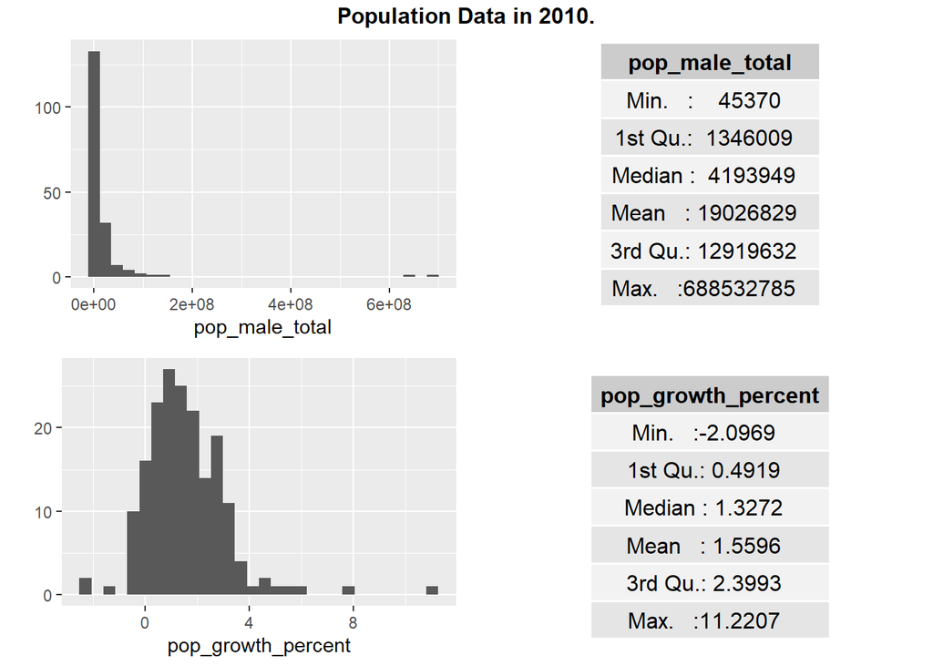

```r
selfharm_2010 %>%
  select(pop_male_total) %>%
  summary() %>% as.table() -> t3
selfharm_2010 %>%
  select(pop_growth_percent) %>%
  summary() %>% as.table() -> t4

ax5 <- qplot(data=selfharm_2010, x=pop_male_total, geom='histogram', bins = 30)
ax6 <- ggplot(selfharm_2010, aes(pop_female_total)) +
  annotation_custom(tableGrob(t3, rows=NULL),
                    xmin=0, xmax=Inf, ymin=0.05, ymax=Inf) +
  theme(plot.caption = element_text(hjust = 0)) +
  theme_void()

ax7 <- qplot(data=selfharm_2010, x=pop_growth_percent, geom='histogram', bins = 30)
ax8 <- ggplot(selfharm_2010, aes(pop_female_total)) +
  annotation_custom(tableGrob(t4, rows=NULL),
                    xmin=0, xmax=Inf, ymin=-0.05, ymax=Inf) +
  theme(plot.caption = element_text(hjust = 0)) +
  theme_void()

grid.arrange(ax5,ax6,ax7,ax8,
             top = textGrob('Population Data in 2010.',
                            gp=gpar(fontface = 'bold')))
```

```r
remove(ax5,ax6,ax7,ax8,t3,t4)
```

## Population continued

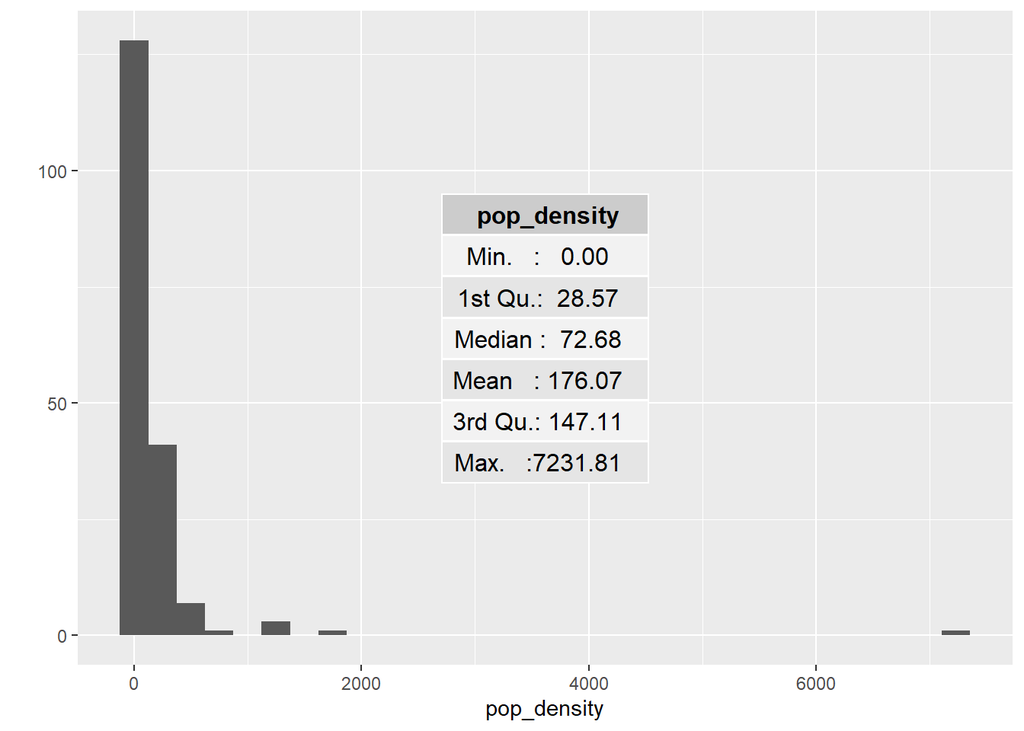

```r
selfharm_2010 %>%
  select(pop_density) %>%
  summary() %>% as.table() -> t5


qplot(data=selfharm_2010, x=pop_density, geom='histogram', bins = 30) +
  annotation_custom(tableGrob(t5, rows=NULL))
```

```r
remove(t5)
```

## Education

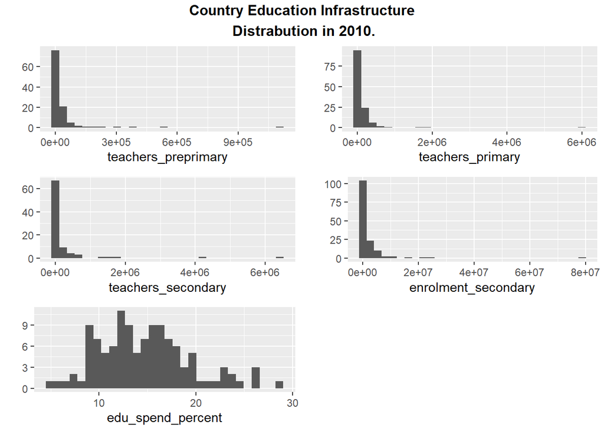

```r
# selfharm_2010 %>%
#   summarise_at(vars(c('teachers_preprimary','teachers_primary',
#                       'teachers_secondary', 'enrolment_secondary',
#                       'edu_spend_percent')),
#                .funs = sum(is.na(.)))
ax1 <- qplot(data=selfharm_2010, x=teachers_preprimary, geom='histogram',bins = 30)
ax2 <- qplot(data=selfharm_2010, x=teachers_primary, geom='histogram',bins = 30)
ax3 <- qplot(data=selfharm_2010, x=teachers_secondary, geom='histogram',bins = 30)
ax4 <- qplot(data=selfharm_2010, x=enrolment_secondary, geom='histogram',bins = 30)
ax5 <- qplot(data=selfharm_2010, x=edu_spend_percent, geom='histogram',bins = 30)
grid.arrange(ax1,ax2,ax3,ax4,ax5,
             top = textGrob('Country Education Infrastructure\n Distrabution in 2010.',
                            gp=gpar(fontface = 'bold')))
```

```r
remove(ax1,ax2,ax3,ax4,ax5)
```

## teachers_preprimary > (26992-1764)*3

```r
selfharm_2010 %>%
  select(c(teachers_preprimary, teachers_primary, teachers_secondary,
           enrolment_secondary, edu_spend_percent)) %>%
  summary()
```

```
##  teachers_preprimary teachers_primary  teachers_secondary
##  Min.   :     79     Min.   :    677   Min.   :    592
##  1st Qu.:   1764     1st Qu.:   7982   1st Qu.:   7977
##  Median :   7591     Median :  35017   Median :  40829
##  Mean   :  41002     Mean   : 159101   Mean   : 260264
##  3rd Qu.:  26992     3rd Qu.: 116950   3rd Qu.: 100425
##  Max.   :1105730     Max.   :5997393   Max.   :6417038
##  NA's   :71          NA's   :52        NA's   :94
##  enrolment_secondary edu_spend_percent
##  Min.   :    7554    Min.   : 5.292
##  1st Qu.:  139207    1st Qu.:11.543
##  Median :  484368    Median :14.328
##  Mean   : 2260725    Mean   :14.655
##  3rd Qu.: 1656163    3rd Qu.:17.251
##  Max.   :78798728    Max.   :29.018
##  NA's   :37          NA's   :65
```

```r
#   ggplot(x=0:10,y=0:10, geom='blank') +
#   annotation_custom(tableGrob(t, rows=NULL))
# remove(t)
selfharm_2010 %>% filter(teachers_preprimary > (26992-1764)*3) %>% select(country)
```

```
## # A tibble: 10 x 1
##    country
##    <fct>
##  1 Brazil
##  2 China
##  3 France
##  4 Germany
##  5 Indonesia
##  6 Japan
##  7 Kenya
##  8 Mexico
##  9 Ukraine
## 10 USA
```

## Economic Measures

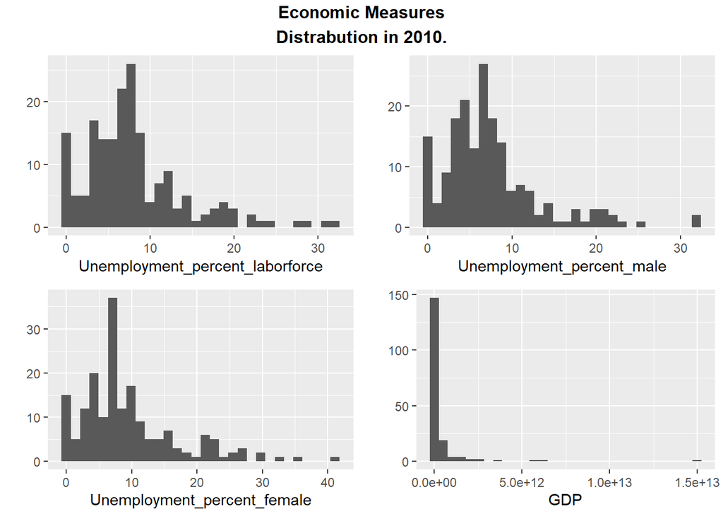

```r
ax1 <- qplot(data=selfharm_2010, x=Unemployment_percent_laborforce, geom='histogram',bins = 30)
ax2 <- qplot(data=selfharm_2010, x=Unemployment_percent_male, geom='histogram',bins = 30)
ax3 <- qplot(data=selfharm_2010, x=Unemployment_percent_female, geom='histogram',bins = 30)
ax4 <- qplot(data=selfharm_2010, x=GDP, geom='histogram',bins = 30)
grid.arrange(ax1,ax2,ax3,ax4,
             top = textGrob('Economic Measures\nDistrabution in 2010.',
                            gp=gpar(fontface = 'bold')))
```

## Technology Prevalence

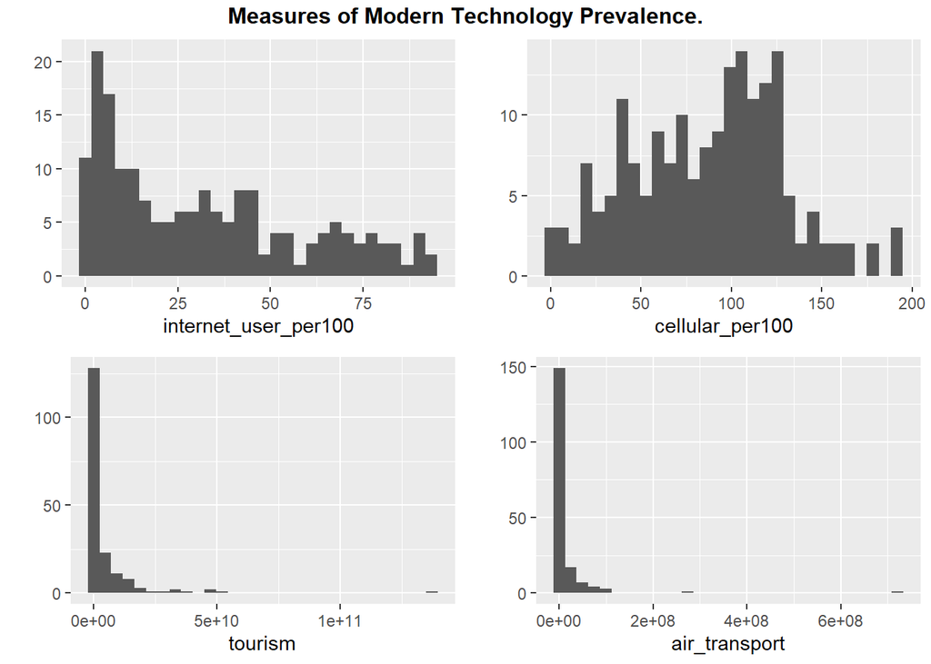

```r
ax1 <- qplot(data=selfharm_2010, x=internet_user_per100, geom='histogram',bins = 30)
ax2 <- qplot(data=selfharm_2010, x=cellular_per100, geom='histogram',bins = 30)
ax3 <- qplot(data=selfharm_2010, x=tourism, geom='histogram',bins = 30)
ax4 <- qplot(data=selfharm_2010, x=air_transport, geom='histogram',bins = 30)
grid.arrange(ax1,ax2,ax3,ax4,
             top = textGrob('Measures of Modern Technology Prevalence.',
                            gp=gpar(fontface = 'bold')))
```

## Representative sample

```r
# fills <- c('Selfharm count' = 'blue', 'Selfharm rate' = 'deepskyblue4')
# select(nested_fit_1$data[[2]],country)
# nested_fit_1$data[[2]] %>%
#   filter_at(vars(c('growth', 'netUsers', 'female', 'male', 'density',
#                    'tourism', 'cell', 'air', 'pop', 'Unemployment',
#                    'UnemployMale', 'UnemployFemale', 'GDP', 'dying',
#                    'suicide_rate')), all_vars(!is.na(.))) %>%
#   select(country) %>%
#   as.character() -> sample_2010
```

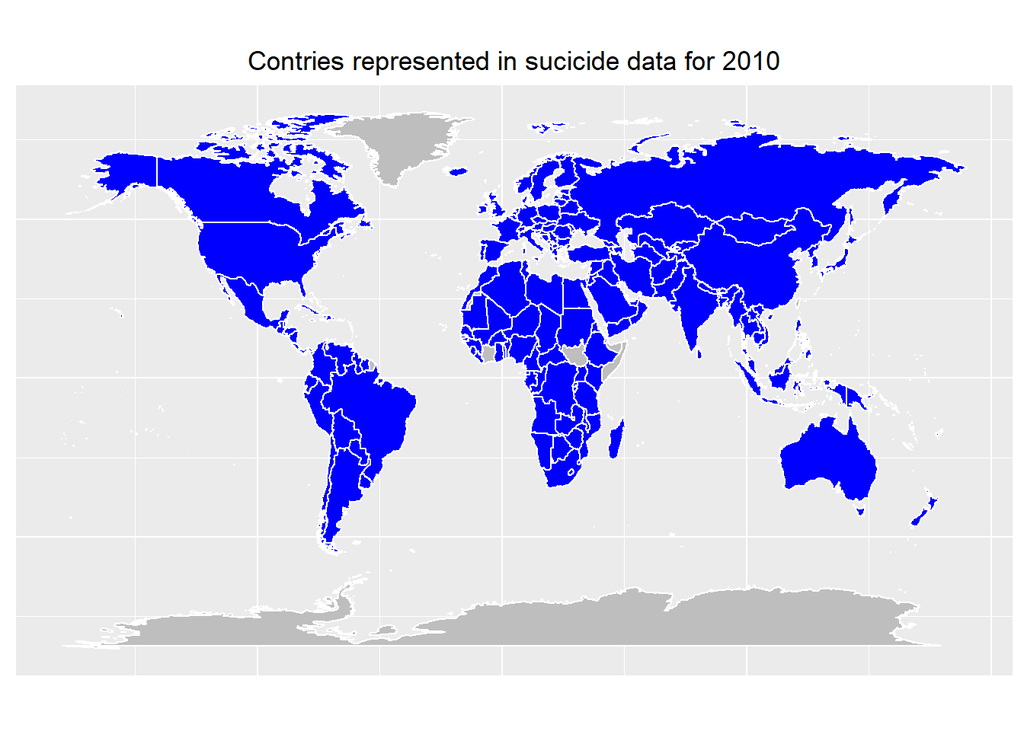

```r
sample_2010 <- selfharm_2010 %>%
  rename(pop = population, spend = edu_spend_percent, growth = pop_growth_percent,
         netUsers = internet_user_per100, preprimary = teachers_preprimary,
         secondary = teachers_secondary, primary = teachers_primary,
         enrol = enrolment_secondary, female = pop_female_total, male = pop_male_total,
         density = pop_density,  cell = cellular_per100, air = air_transport,
         Unemployment = Unemployment_percent_laborforce, UnemployMale = Unemployment_percent_male,
         UnemployFemale = Unemployment_percent_female, dying = Probability_30to70_dying) %>%
  select(c(country, growth, netUsers, female, male, density,
           tourism, cell, air, pop, Unemployment, UnemployMale,
           UnemployFemale, GDP, dying, suicide_rate)) %>%
  drop_na() %>%
  select(country)

ggplot(worldMap_selfharm, aes(x = long, y = lat, group = group)) +
  geom_polygon(color = 'white', fill = 'gray') +
  geom_polygon(data = filter(worldMap_selfharm, region %in% sample_2010$country),
               fill = 'blue', color = 'white') +
  coord_fixed(1.3) +
  labs(title = 'Contries represented in sucicide data for 2010') +
  theme(plot.title = element_text(hjust = 0.5),
        plot.caption = element_text(hjust = 0),
        axis.text = element_blank(),
        axis.title = element_blank(),
        axis.ticks = element_blank())
```

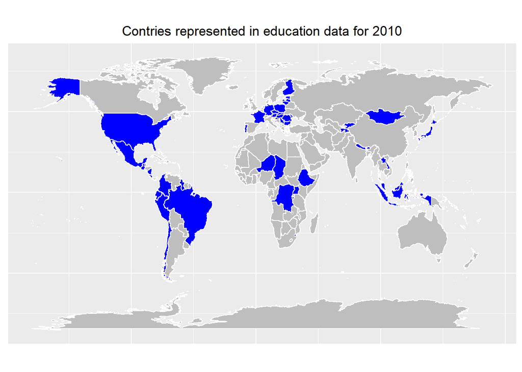

```r
sample_2010L <- selfharm_2010 %>%
  rename(pop = population, spend = edu_spend_percent, growth = pop_growth_percent,
         netUsers = internet_user_per100, preprimary = teachers_preprimary,
         secondary = teachers_secondary, primary = teachers_primary,
         enrol = enrolment_secondary, female = pop_female_total, male = pop_male_total,
         density = pop_density,  cell = cellular_per100, air = air_transport,
         Unemployment = Unemployment_percent_laborforce, UnemployMale = Unemployment_percent_male,
         UnemployFemale = Unemployment_percent_female, dying = Probability_30to70_dying) %>%
  select(c(country, growth, netUsers, female, male, density,
           tourism, cell, air, pop, Unemployment, UnemployMale,
           UnemployFemale, GDP, dying, spend, preprimary,
           secondary, primary, enrol, suicide_rate)) %>%
  drop_na() %>%
  select(country)

ggplot(worldMap_selfharm, aes(x = long, y = lat, group = group)) +
  geom_polygon(color = 'white', fill = 'gray') +
  geom_polygon(data = filter(worldMap_selfharm, region %in% sample_2010L$country),
               fill = 'blue', color = 'white') +
  coord_fixed(1.3) +
  labs(title = 'Contries represented in education data for 2010') +
  theme(plot.title = element_text(hjust = 0.5),
        plot.caption = element_text(hjust = 0),
        axis.text = element_blank(),
        axis.title = element_blank(),
        axis.ticks = element_blank())
```

# Model selection

```r
# Nested data by year with abreveated names
selfharm_nest <- selfharm_dat  %>%
  select(-c(population_total_edu, suicide_per100k,
            suicide_ageadj, suicide_count, precipitation)) %>%
  rename(pop = population_totl_WID, spend = edu_spend_percent, growth = pop_growth_percent,
         netUsers = internet_user_per100, preprimary = teachers_preprimary,
         secondary = teachers_secondary, primary = teachers_primary,
         enrol = enrolment_secondary, female = pop_female_total, male = pop_male_total,
         density = pop_density,  cell = cellular_per100, air = air_transport,
         Unemployment = Unemployment_percent_laborforce, UnemployMale = Unemployment_percent_male,
         UnemployFemale = Unemployment_percent_female, dying = Probability_30to70_dying) %>%
  filter(!is.na(suicide_rate), year != 2016) %>%
  group_by(year) %>%
  nest()

# summary(selfharm_nest$data[[2]])
# selfharm_nest$year
```

```r
# Nested stepwise model fitting
DV = 'suicide_rate'
# IVs = c('spend', 'growth', 'netUsers', 'preprimary', 'secondary', 'primary',
#         'enrol', 'female', 'male', 'density', 'tourism', 'cell', 'air', 'pop',
#         'Unemployment', 'UnemployMale', 'UnemployFemale', 'GDP', 'dying', 'suicide_rate')
# edu_IVs = c('spend', 'preprimary', 'secondary', 'primary', 'enrol')
IVs = c('growth', 'netUsers', 'female', 'male', 'density', 'tourism', 'cell', 'air', 'pop',
        'Unemployment', 'UnemployMale', 'UnemployFemale', 'GDP', 'dying')



nested_fit_1 <- selfharm_nest %>%
  mutate(model = purrr::map(data, ~ z.step(dat = ., DV = DV, IVs = IVs)),
         results = purrr::map(model, ~ broom::tidy(x = ., conf.int = TRUE, conf.level = 0.95)),
         diagnostics = purrr::map(model, glance))
```

```
## Start:  AIC=752.41
## suicide_rate ~ 1
##
##                  Df Sum of Sq     RSS    AIC
## + growth          1   3078.41  9909.4 707.34
## + netUsers        1    578.03 12409.7 746.49
## + cell            1    550.00 12437.8 746.88
## + dying           1    549.99 12437.8 746.88
## + UnemployMale    1    278.55 12709.2 750.64
## <none>                        12987.8 752.41
## + Unemployment    1     78.92 12908.9 753.35
## + GDP             1     74.13 12913.6 753.42
## + female          1     66.86 12920.9 753.51
## + pop             1     60.53 12927.3 753.60
## + male            1     54.49 12933.3 753.68
## + tourism         1     39.82 12948.0 753.88
## + air             1     21.93 12965.8 754.12
## + UnemployFemale  1     19.48 12968.3 754.15
## + density         1      3.99 12983.8 754.36
##
## Step:  AIC=707.34
## suicide_rate ~ growth
##
##                  Df Sum of Sq    RSS    AIC
## + dying           1    514.68 9394.7 700.06
## + UnemployFemale  1    123.68 9785.7 707.15
## <none>                        9909.4 707.34
## + netUsers        1     97.40 9812.0 707.62
## + cell            1     73.44 9835.9 708.05
## + female          1     31.63 9877.7 708.78
## + pop             1     28.89 9880.5 708.83
## + male            1     26.39 9883.0 708.88
## + UnemployMale    1      9.05 9900.3 709.18
## + Unemployment    1      8.28 9901.1 709.19
## + tourism         1      6.99 9902.4 709.22
## + GDP             1      5.64 9903.7 709.24
## + density         1      5.20 9904.2 709.25
## + air             1      0.15 9909.2 709.34
##
## Step:  AIC=700.06
```

[output cut: 364 more lines]

```
## + air      1    11.797 5582.1 623.75
## + cell     1     0.193 5593.7 624.12
##
## Step:  AIC=617.15
## suicide_rate ~ growth + netUsers + dying
##
##           Df Sum of Sq    RSS    AIC
## <none>                 5380.0 617.15
## + GDP      1    43.264 5336.8 617.70
## + air      1    21.616 5358.4 618.43
## + female   1    19.651 5360.4 618.49
## + pop      1    18.195 5361.8 618.54
## + density  1    18.082 5362.0 618.55
## + male     1    16.626 5363.4 618.59
## + cell     1     0.908 5379.1 619.12
```

```r
# summary(nested_fit_1$model[[3]])
# glance(stepResult)
# selfharm_nest$year
```

```r
# four ELS stepwise fits in one
print('Nested models')
```

```
## [1] "Nested models"
```

```r
nested_fit_1
```

```
## # A tibble: 4 x 5
## # Groups:   year [5]
##   year             data model  results           diagnostics
##   <fct> <list<df[,21]>> <list> <list>            <list>
## 1 2000       [182 x 21] <lm>   <tibble [5 x 7]>  <tibble [1 x 11]>
## 2 2005       [182 x 21] <lm>   <tibble [11 x 7]> <tibble [1 x 11]>
## 3 2010       [182 x 21] <lm>   <tibble [6 x 7]>  <tibble [1 x 11]>
## 4 2015       [182 x 21] <lm>   <tibble [4 x 7]>  <tibble [1 x 11]>
```

```r
# fit results
print('Results for 2010 fit')
```

```
## [1] "Results for 2010 fit"
```

```r
nested_fit_1$results[[3]] %>%
  select(term:p.value)
```

```
## # A tibble: 6 x 5
##   term           estimate std.error statistic     p.value
##   <chr>             <dbl>     <dbl>     <dbl>       <dbl>
## 1 (Intercept)      -1.49     2.72      -0.547 0.585
## 2 growth           -1.17     0.323     -3.62  0.000379
## 3 netUsers          0.120    0.0220     5.44  0.000000174
## 4 dying             0.487    0.0985     4.95  0.00000177
## 5 UnemployFemale   -0.403    0.152     -2.65  0.00873
## 6 Unemployment      0.421    0.192      2.19  0.0297
```

```r
# diagnostics
print('Diagnostics for 2010 fit')
```

```
## [1] "Diagnostics for 2010 fit"
```

```r
nested_fit_1$diagnostics[[3]]  %>%
  mutate(df = paste(df,df.residual, sep = '/'),
         'AIC/BIC' = paste(round(AIC,1),round(BIC,1), sep='/')) %>%
  select(-c(r.squared, statistic, logLik, df.residual,AIC,BIC))
```

```
## # A tibble: 1 x 6
##   adj.r.squared sigma  p.value df    deviance `AIC/BIC`
##           <dbl> <dbl>    <dbl> <chr>    <dbl> <chr>
## 1         0.325  5.92 1.55e-14 6/174    6091. 1158.7/1181
```

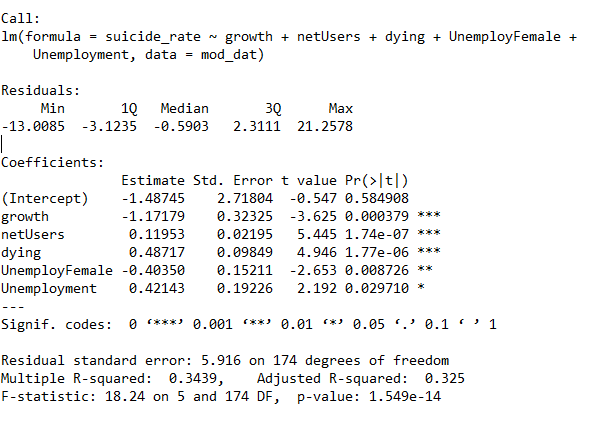

```r
model_dat10 <- z.getModelDat(nested_fit_1$data[[3]],
                           DV = 'suicide_rate',
                            IVs = c('growth', 'netUsers', 'female', 'male', 'density',
                                    'tourism', 'cell', 'air', 'pop', 'Unemployment',
                                    'UnemployMale', 'UnemployFemale', 'GDP', 'dying',
                                    'suicide_rate'))
# Fit
fit_1 <- nested_fit_1$model[[3]]

# tidy results
results_1 <- nested_fit_1$results[[3]]

# tidy diagnostics
diagnostics_1 <- nested_fit_1$diagnostics[[3]]

# DFBETAs
DFBETAs <- as.data.frame(dfbetas(fit_1)) %>%
  select(-`(Intercept)`) %>%
  rename_all( ~ paste0(., ".DFB"))

# DFFITs
DFFITs <- as.data.frame(dffits(fit_1)) %>%
  rename('DFFITs' = 'dffits(fit_1)')

# tidy model data with influence mesasurs
fit_1AUG <- augment(fit_1) %>%
  bind_cols(DFBETAs) %>%
  bind_cols(DFFITs)
```

```r
# selection by exhaustive search
best_subset <- regsubsets(suicide_rate ~ ., model_dat10, nbest=2)
results <- summary(best_subset)
# results table to CSV
stat_tibble <- tibble(fit = sapply(1:16, function(x) paste0(names(coef(best_subset, x))[-1],
                                                             collapse = '+')),
                      adj_R2 = results$adjr2,
                      Cp = results$cp,
                      BIC = results$bic)
stat_tibble
```

```
## # A tibble: 16 x 4
##    fit                                                   adj_R2    Cp   BIC
##    <chr>                                                  <dbl> <dbl> <dbl>
##  1 growth                                                 0.181 43.4  -26.6
##  2 netUsers                                               0.104 64.2  -10.3
##  3 netUsers+dying                                         0.231 31.0  -33.7
##  4 growth+netUsers                                        0.220 33.7  -31.2
##  5 growth+netUsers+dying                                  0.304 12.4  -47.5
##  6 netUsers+UnemployFemale+dying                          0.233 31.2  -30.1
##  7 growth+netUsers+UnemployFemale+dying                   0.310 11.7  -45.0
##  8 growth+netUsers+cell+dying                             0.305 13.2  -43.5
##  9 growth+netUsers+Unemployment+UnemployFemale+dying      0.325  8.78 -44.7
## 10 growth+netUsers+UnemployMale+UnemployFemale+dying      0.323  9.30 -44.2
## 11 growth+netUsers+air+UnemployFemale+GDP+dying           0.328  9.05 -41.3
## 12 growth+netUsers+female+male+air+dying                  0.327  9.38 -40.9
## 13 growth+netUsers+air+Unemployment+UnemployFemale+GDP+~  0.346  5.21 -42.2
## 14 growth+netUsers+air+UnemployMale+UnemployFemale+GDP+~  0.345  5.56 -41.8
## 15 growth+netUsers+female+male+air+Unemployment+Unemplo~  0.345  6.57 -37.7
## 16 growth+netUsers+female+male+air+UnemployMale+Unemplo~  0.344  6.85 -37.4
```

```r
# write_csv(stat_tibble, paste0(fpath, "selfharm_rate_best_subset.csv"))
```

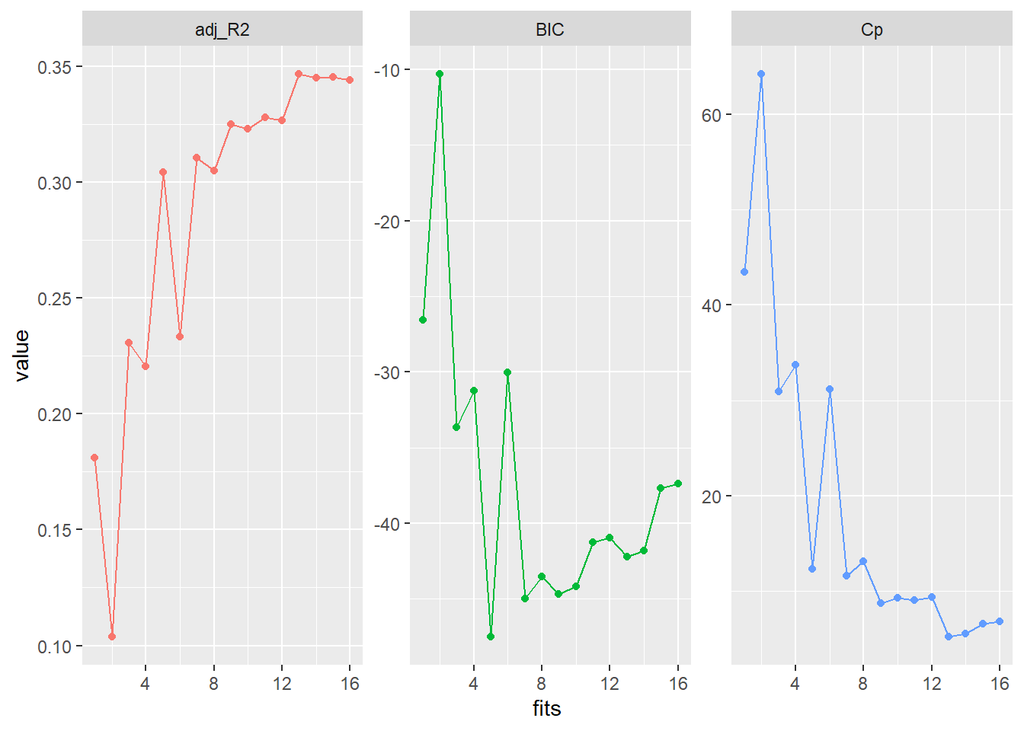

```r
# visualisation of results
tibble(fits = 1:16,
       adj_R2 = results$adjr2,
       Cp = results$cp,
       BIC = results$bic) %>%
  gather(statistic, value, -fits) %>%
  ggplot(aes(fits, value, color = statistic)) +
  geom_line(show.legend = F) +
  geom_point(show.legend = F) +
  facet_wrap(~ statistic, scales = "free")
```

## Residual Analysis

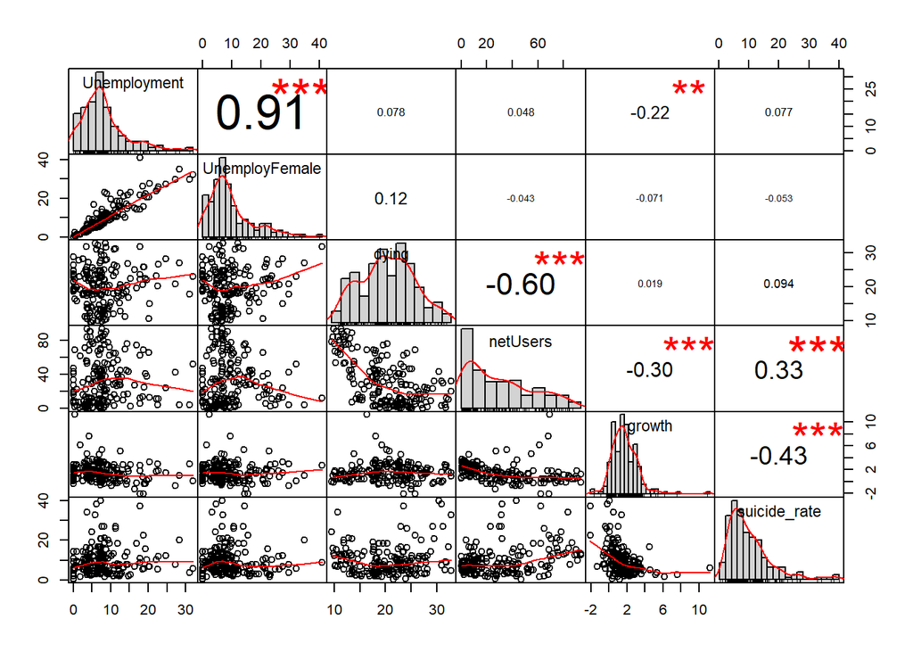

```r
fit_1AUG %>%
  select(Unemployment:suicide_rate) %>%
  chart.Correlation(., histogram=TRUE, method = "pearson")
```

```r
print('VIFs')
```

```
## [1] "VIFs"
```

```r
vif(fit_1)
```

```
##         growth       netUsers          dying UnemployFemale   Unemployment
##       1.299078       1.803182       1.641837       6.788646       7.049083
```

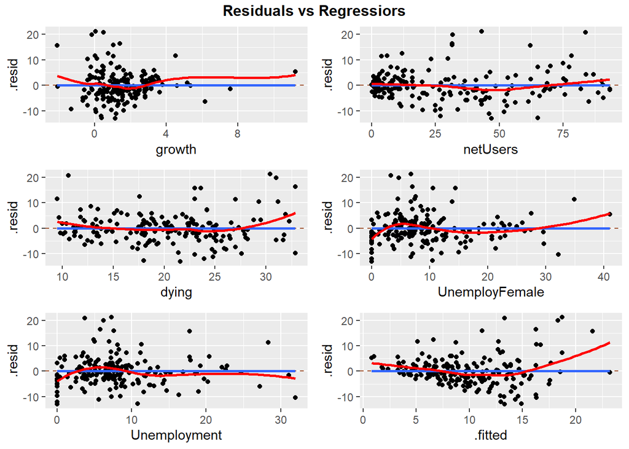

```r
# fit_1.3AUG$.fitted  UnemployFemale
fig <- ggplot(fit_1AUG, aes(y=.resid)) +
  geom_hline(yintercept = 0, color = "sienna", linetype="dashed")

ax1 <- fig + geom_point(aes(x = growth)) +
  geom_smooth(aes(x = growth), method = "lm", se = FALSE) +
  geom_smooth(aes(x = growth), method = 'loess', color='red', se = FALSE)
ax2 <- fig + geom_point(aes(x = netUsers)) +
  geom_smooth(aes(x = netUsers), method = "lm", se = FALSE) +
  geom_smooth(aes(x = netUsers), method = 'loess', color='red', se = FALSE)
ax3 <- fig + geom_point(aes(x = dying)) +
  geom_smooth(aes(x = dying),method = "lm", se = FALSE) +
  geom_smooth(aes(x = dying), method = 'loess', color='red', se = FALSE)
ax4 <- fig + geom_point(aes(x = UnemployFemale)) +
  geom_smooth(aes(x = UnemployFemale),method = "lm", se = FALSE) +
  geom_smooth(aes(x = UnemployFemale), method = 'loess', color='red', se = FALSE)
ax5 <- fig + geom_point(aes(x = Unemployment)) +
  geom_smooth(aes(x = Unemployment),method = "lm", se = FALSE) +
  geom_smooth(aes(x = Unemployment), method = 'loess', color='red', se = FALSE)
ax6 <- fig + geom_point(aes(x = .fitted)) +
  geom_smooth(aes(x = .fitted),method = "lm", se = FALSE) +
  geom_smooth(aes(x = .fitted), method = 'loess', color='red', se = FALSE)

grid.arrange(ax1,ax2,ax3,ax4,ax5,ax6,
             top = textGrob('Residuals vs Regressiors',
                            gp=gpar(fontface = 'bold')))
```

```r
remove(fig,ax1,ax2,ax3,ax4,ax5,ax6)
```

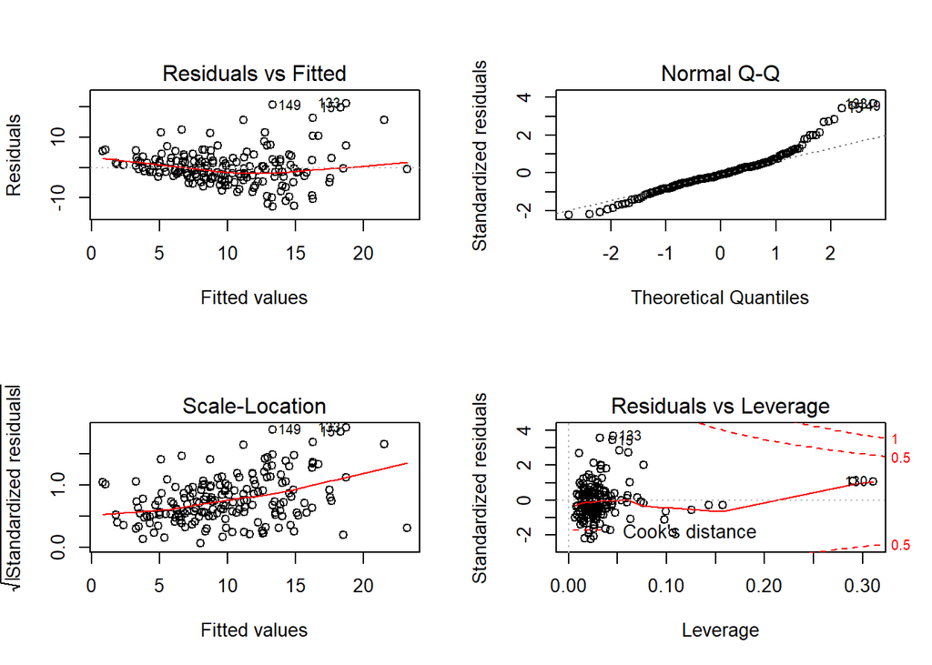

```r
par(mfrow=c(2,2))
plot(fit_1)
```

1. Non-constant variance
2. Normality
3. Outlier, leverage, infulence.

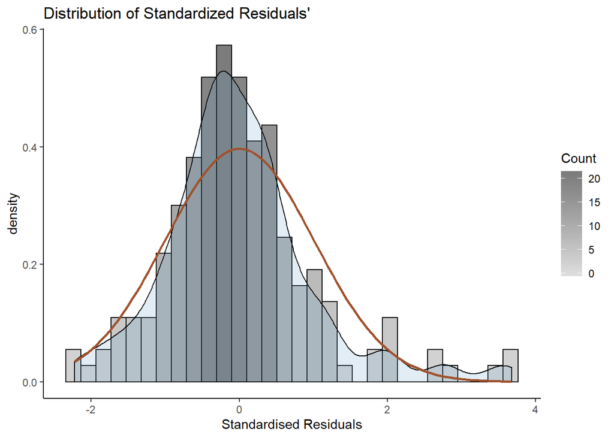

```r
ggplot(fit_1AUG, aes(x = .std.resid)) +
  geom_histogram(bins=30, colour = "black", aes(y=..density..,fill = ..count..)) +
  scale_fill_gradient("Count", low = "#DCDCDC", high = "#7C7C7C") +
  geom_density(fill = 'skyblue3', alpha = 0.2) +
  stat_function(fun = dnorm,
                args = list(mean = mean(fit_1AUG$.std.resid), sd = sd(fit_1AUG$.std.resid)),
                color = "sienna", size=1) +
  labs(title = "Distribution of Standardized Residuals'",x = 'Standardised Residuals') +
  theme_classic()
```

## Addressing Multicollinearity

```r
# Refit with out unemploy
fit_1.1 <- lm(suicide_rate ~ growth + netUsers + dying + UnemployFemale, data = model_dat10)

# tidy results
results_1.1 <- broom::tidy(fit_1.1, conf.int = TRUE, conf.level = 0.95)

# tidy diagnostics
diagnostics_1.1 <- glance(fit_1.1)

# DFBETAs
DFBETAs <- as.data.frame(dfbetas(fit_1.1)) %>%
  select(-`(Intercept)`) %>%
  rename_all( ~ paste0(., ".DFB"))

# DFFITs
DFFITs <- as.data.frame(dffits(fit_1.1)) %>%
  rename('DFFITs' = 'dffits(fit_1.1)')

# tidy model data with influence mesasurs
fit_1.1AUG <- augment(fit_1.1) %>%
  bind_cols(DFBETAs) %>%
  bind_cols(DFFITs)

 # Compare Diagnostics
# cbind(Model=c("fit_1","fit_1.1"),
#       rbind(select(diagnostics_1, -c(r.squared, statistic, logLik)),
#             select(diagnostics_1.1, -c(r.squared, statistic, logLik))))
#
# vif(fit_1.1)
```

```r
# Refit with out unemploy
fit_1.2 <- lm(suicide_rate ~ growth + netUsers + dying + Unemployment, data = model_dat10)

# tidy results
results_1.2 <- broom::tidy(fit_1.2, conf.int = TRUE, conf.level = 0.95)

# tidy diagnostics
diagnostics_1.2 <- glance(fit_1.2)

# DFBETAs
DFBETAs <- as.data.frame(dfbetas(fit_1.2)) %>%
  select(-`(Intercept)`) %>%
  rename_all( ~ paste0(., ".DFB"))

# DFFITs
DFFITs <- as.data.frame(dffits(fit_1.2)) %>%
  rename('DFFITs' = 'dffits(fit_1.2)')

# tidy model data with influence mesasurs
fit_1.2AUG <- augment(fit_1.2) %>%
  bind_cols(DFBETAs) %>%
  bind_cols(DFFITs)

 # Compare Diagnostics
# cbind(Model=c("fit_1","fit_1.1","fit_1.2"), rbind(diagnostics_1,diagnostics_1.1,diagnostics_1.2))
#
# vif(fit_1.2)
```

```r
# Refit with out unemploy
fit_1.3 <- lm(suicide_rate ~ growth + netUsers + dying , data = model_dat10)

# tidy results
results_1.3 <- broom::tidy(fit_1.3, conf.int = TRUE, conf.level = 0.95)

# tidy diagnostics
diagnostics_1.3 <- glance(fit_1.3)

# DFBETAs
DFBETAs <- as.data.frame(dfbetas(fit_1.3)) %>%
  select(-`(Intercept)`) %>%
  rename_all( ~ paste0(., ".DFB"))

# DFFITs
DFFITs <- as.data.frame(dffits(fit_1.3)) %>%
  rename('DFFITs' = 'dffits(fit_1.3)')

# tidy model data with influence mesasurs
fit_1.3AUG <- augment(fit_1.3) %>%
  bind_cols(DFBETAs) %>%
  bind_cols(DFFITs)
```

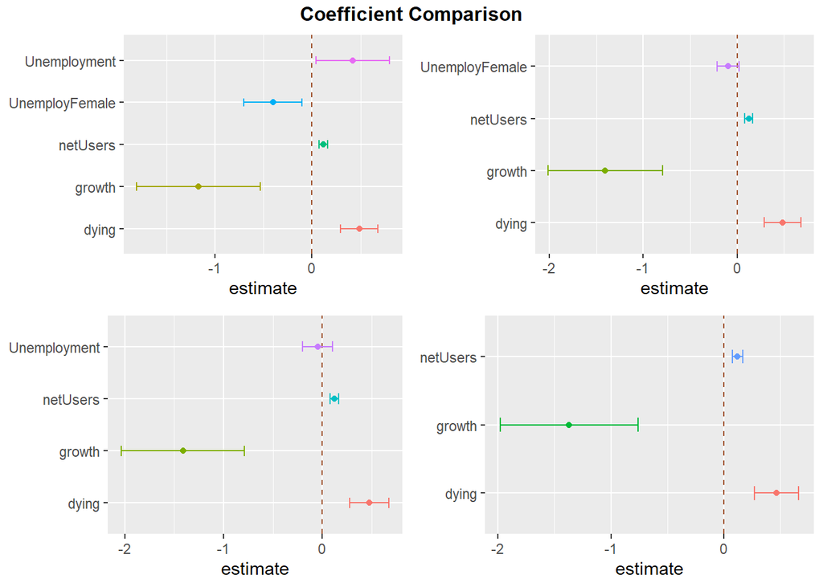

```r
# visual comparison of margonal coeff
grid.arrange(z.plotMargin_results(results_1, title = NULL),
             z.plotMargin_results(results_1.1, title = NULL),
             z.plotMargin_results(results_1.2, title = NULL),
             z.plotMargin_results(results_1.3, title = NULL),
             top = textGrob('Coefficient Comparison',
                            gp=gpar(fontface = 'bold')))
```

```r
# Compare Diagnostics
cbind(Model=c("fit_1","fit_1.1","fit_1.2", "fit_1.3"),
      rbind(diagnostics_1,
            diagnostics_1.1,
            diagnostics_1.2,
            diagnostics_1.3)) %>%
  mutate(df = paste(df,df.residual, sep = '/'),
         'AIC/BIC' = paste(round(AIC,1),round(BIC,1), sep='/')) %>%
  select(-c(r.squared, statistic, logLik, df.residual,AIC,BIC))
```

```
##     Model adj.r.squared    sigma      p.value    df deviance       AIC/BIC
## 1   fit_1     0.3250474 5.916346 1.548719e-14 6/174 6090.549   1158.7/1181
## 2 fit_1.1     0.3103732 5.980314 3.089148e-14 5/175 6258.728 1161.6/1180.8
## 3 fit_1.2     0.3017660 6.017518 8.916871e-14 5/175 6336.843   1163.8/1183
## 4 fit_1.3     0.3040973 6.007464 1.904273e-14 4/176 6351.774 1162.3/1178.2
```

## Fit_1 compared to fit_1.3

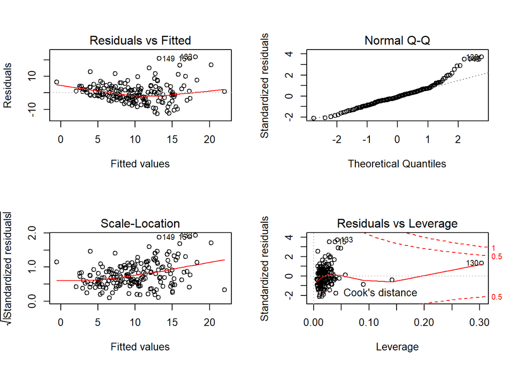

```r
par(mfrow=c(2,2))
# plot(fit_1, c(1,2))
plot(fit_1.3)
```

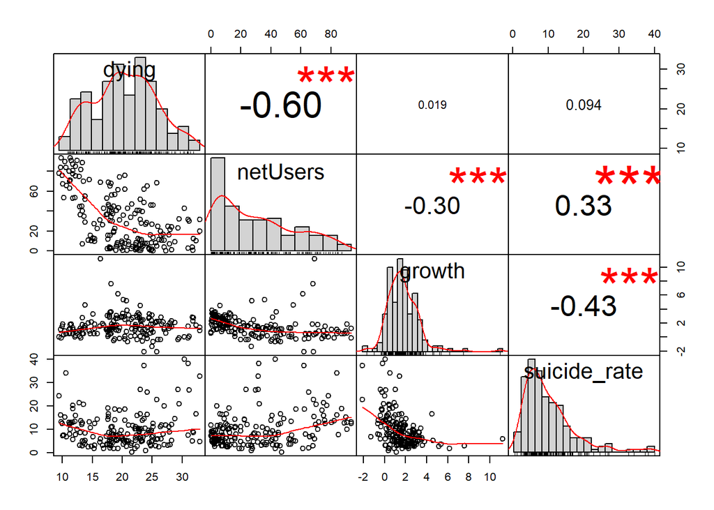

```r
fit_1.3AUG %>%
  select(dying:suicide_rate) %>%
  chart.Correlation(., histogram=TRUE, method = "pearson")
```

```r
print('VIFs')
```

```
## [1] "VIFs"
```

```r
vif(fit_1.3)
```

```
##   growth netUsers    dying
## 1.154087 1.790034 1.624933
```

```r
print(paste('1/(1-0.4415) = ', round(1/(1-0.4415),4)))
```

```
## [1] "1/(1-0.4415) =  1.7905"
```

## Non-constent varience

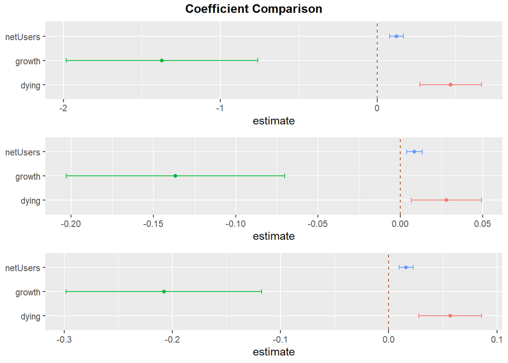

```r
# Refit with out unemploy
fit_1.4 <- lm(log(suicide_rate) ~ growth + netUsers + dying, data = model_dat10)
fit_1.5 <- lm(sqrt(suicide_rate) ~ growth + netUsers + dying, data = model_dat10)

# tidy results
results_1.4 <- broom::tidy(fit_1.4, conf.int = TRUE, conf.level = 0.95)
results_1.5 <- broom::tidy(fit_1.5, conf.int = TRUE, conf.level = 0.95)

# tidy diagnostics
diagnostics_1.4 <- glance(fit_1.4)
diagnostics_1.5 <- glance(fit_1.5)

# DFBETAs
DFBETAs <- as.data.frame(dfbetas(fit_1.4)) %>%
  select(-`(Intercept)`) %>%
  rename_all( ~ paste0(., ".DFB"))
# DFFITs
DFFITs <- as.data.frame(dffits(fit_1.4)) %>%
  rename('DFFITs' = 'dffits(fit_1.4)')
# tidy model data with influence mesasurs
fit_1.4AUG <- augment(fit_1.4) %>%
  bind_cols(DFBETAs) %>%
  bind_cols(DFFITs)

remove(DFBETAs, DFFITs)

# DFBETAs
DFBETAs <- as.data.frame(dfbetas(fit_1.5)) %>%
  select(-`(Intercept)`) %>%
  rename_all( ~ paste0(., ".DFB"))
# DFFITs
DFFITs <- as.data.frame(dffits(fit_1.5)) %>%
  rename('DFFITs' = 'dffits(fit_1.5)')
# tidy model data with influence mesasurs
fit_1.5AUG <- augment(fit_1.5) %>%
  bind_cols(DFBETAs) %>%
  bind_cols(DFFITs)

remove(DFBETAs, DFFITs)

# visual comparison of margonal coeff
grid.arrange(z.plotMargin_results(results_1.3, title = NULL),
             z.plotMargin_results(results_1.4, title = NULL),
             z.plotMargin_results(results_1.5, title = NULL),
             nrow = 3,
             top = textGrob('Coefficient Comparison',
                            gp=gpar(fontface = 'bold')),
             widths = c(3), heights = c(1,1,1))
```

```r
# Compare Diagnostics
cbind(Model=c("fit_1.3","log(y)", "sqrt(y)"),
      rbind(diagnostics_1.3,
            diagnostics_1.4,
            diagnostics_1.5)) %>%
  mutate_if(is.numeric,~ round(.,3)) %>%
  mutate(df = paste(df,df.residual, sep = '/'),
         'AIC / BIC' = paste(round(AIC,1),round(BIC,1), sep=' / ')) %>%
  select(-c(r.squared, statistic, logLik, df.residual,AIC,BIC))
```

```
##     Model adj.r.squared sigma p.value    df deviance       AIC / BIC
## 1 fit_1.3         0.304 6.007       0 4/176 6351.774 1162.3 / 1178.2
## 2  log(y)         0.194 0.653       0 4/176   74.970   363.2 / 379.1
## 3 sqrt(y)         0.276 0.888       0 4/176  138.768       474 / 490
```

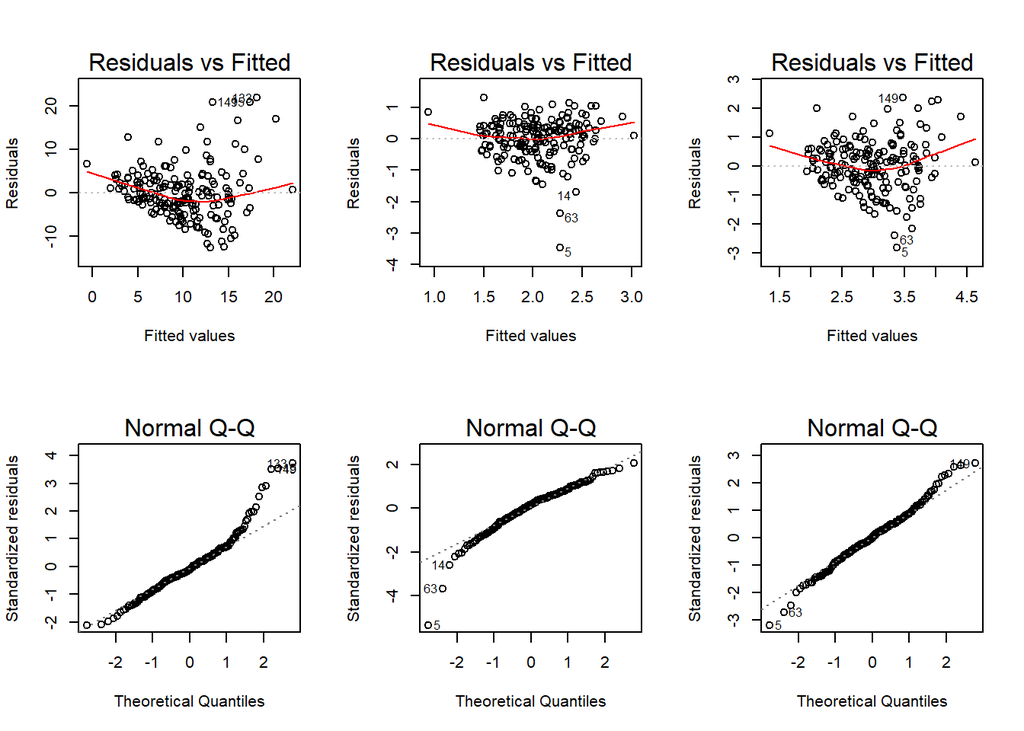

```r
## Figure 2
par(mfrow=c(2,3))
plot(fit_1.3, 1)
plot(fit_1.4, 1)
plot(fit_1.5, 1)
plot(fit_1.3, 2)
plot(fit_1.4, 2)
plot(fit_1.5, 2)
```

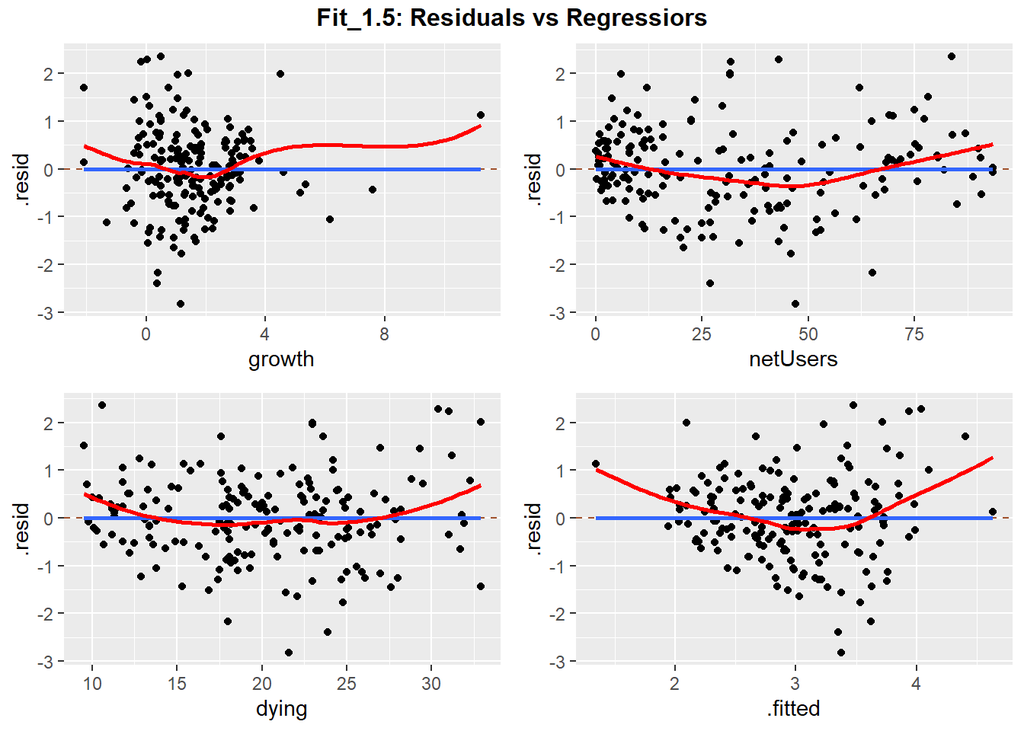

```r
fig <- ggplot(fit_1.5AUG, aes(y=.resid)) +
  geom_hline(yintercept = 0, color = "sienna", linetype="dashed")

ax1 <- fig + geom_point(aes(x = growth)) +
  geom_smooth(aes(x = growth), method = "lm", se = FALSE) +
  geom_smooth(aes(x = growth), method = 'loess', color='red', se = FALSE)
ax2 <- fig + geom_point(aes(x = netUsers)) +
  geom_smooth(aes(x = netUsers), method = "lm", se = FALSE) +
  geom_smooth(aes(x = netUsers), method = 'loess', color='red', se = FALSE)
ax3 <- fig + geom_point(aes(x = dying)) +
  geom_smooth(aes(x = dying),method = "lm", se = FALSE) +
  geom_smooth(aes(x = dying), method = 'loess', color='red', se = FALSE)
ax4 <- fig + geom_point(aes(x = .fitted)) +
  geom_smooth(aes(x = .fitted),method = "lm", se = FALSE) +
  geom_smooth(aes(x = .fitted), method = 'loess', color='red', se = FALSE)

grid.arrange(ax1,ax2,ax3,ax4,
             top = textGrob('Fit_1.5: Residuals vs Regressiors',
                            gp=gpar(fontface = 'bold')))
```

```r
remove(fig,ax1,ax2,ax3,ax4)
```

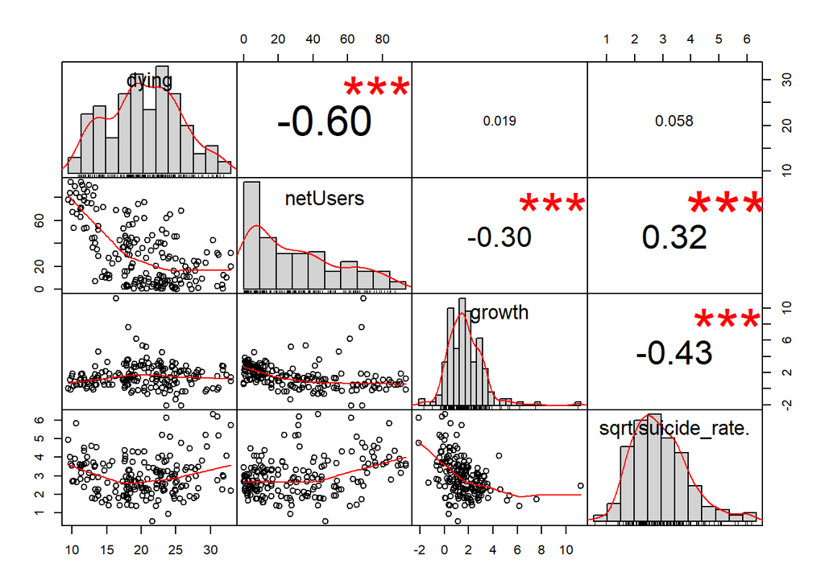

```r
fit_1.5AUG %>%
  select(dying:sqrt.suicide_rate.) %>%
  chart.Correlation(., histogram=TRUE, method = "pearson")
```

```r
print('VIFs')
```

```
## [1] "VIFs"
```

```r
vif(fit_1.5)
```

```
##   growth netUsers    dying
## 1.154087 1.790034 1.624933
```

## WLS

```r
wts <- 1/fitted(lm(abs(fit_1.5AUG$.resid) ~ fit_1.5AUG$growth))^2
# Refit with out unemploy
fit_1.6 <- lm(sqrt(suicide_rate) ~ growth + netUsers + dying,
              data = model_dat10,
              weights = wts)

# tidy results
results_1.6 <- broom::tidy(fit_1.6, conf.int = TRUE, conf.level = 0.95)

# tidy diagnostics
diagnostics_1.6 <- glance(fit_1.6)

# DFBETAs
DFBETAs <- as.data.frame(dfbetas(fit_1.6)) %>%
  select(-`(Intercept)`) %>%
  rename_all( ~ paste0(., ".DFB"))

# DFFITs
DFFITs <- as.data.frame(dffits(fit_1.6)) %>%
  rename('DFFITs' = 'dffits(fit_1.6)')

# tidy model data with influence mesasurs
fit_1.6AUG <- augment(fit_1.6) %>%
  bind_cols(DFBETAs) %>%
  bind_cols(DFFITs)

 # Compare Diagnostics
cbind(Model=c("fit_1.3","fit_1.5","fit_1.6"),
      rbind(diagnostics_1.3,diagnostics_1.5, diagnostics_1.6)) %>%
  mutate_if(is.numeric,~ round(.,3)) %>%
  mutate(df = paste(df,df.residual, sep = '/'),
         'AIC / BIC' = paste(round(AIC,1),round(BIC,1), sep=' / ')) %>%
  select(-c(r.squared, statistic, logLik, df.residual,AIC,BIC))
```

```
##     Model adj.r.squared sigma p.value    df deviance       AIC / BIC
## 1 fit_1.3         0.304 6.007       0 4/176 6351.774 1162.3 / 1178.2
## 2 fit_1.5         0.276 0.888       0 4/176  138.768       474 / 490
## 3 fit_1.6         0.239 1.317       0 4/176  305.096   472.5 / 488.5
```

```r
print('fit_1.3')
```

```
## [1] "fit_1.3"
```

```r
results_1.3 %>%
  select(term:p.value) %>%
  mutate_if(is.numeric,~ round(.,3))
```

```
## # A tibble: 4 x 5
##   term        estimate std.error statistic p.value
##   <chr>          <dbl>     <dbl>     <dbl>   <dbl>
## 1 (Intercept)   -1.39      2.71     -0.512   0.609
## 2 growth        -1.37      0.309    -4.43    0
## 3 netUsers       0.123     0.022     5.55    0
## 4 dying          0.47      0.099     4.72    0
```

```r
print('fit_1.5: sqrt(y)')
```

```
## [1] "fit_1.5: sqrt(y)"
```

```r
results_1.5 %>%
  select(term:p.value) %>%
  mutate_if(is.numeric,~ round(.,3))
```

```
## # A tibble: 4 x 5
##   term        estimate std.error statistic p.value
##   <chr>          <dbl>     <dbl>     <dbl>   <dbl>
## 1 (Intercept)    1.63      0.401      4.07       0
## 2 growth        -0.208     0.046     -4.54       0
## 3 netUsers       0.016     0.003      4.90       0
## 4 dying          0.057     0.015      3.86       0
```

```r
print('fit_1.6: sqrt(y)|weights')
```

```
## [1] "fit_1.6: sqrt(y)|weights"
```

```r
results_1.6 %>%
  select(term:p.value) %>%
  mutate_if(is.numeric,~ round(.,3))
```

```
## # A tibble: 4 x 5
##   term        estimate std.error statistic p.value
##   <chr>          <dbl>     <dbl>     <dbl>   <dbl>
## 1 (Intercept)    1.53      0.364      4.21       0
## 2 growth        -0.127     0.021     -6.02       0
## 3 netUsers       0.016     0.003      5.68       0
## 4 dying          0.054     0.015      3.71       0
```

Fit_1.6 fit weights given population groth percent by the standard deviation method.

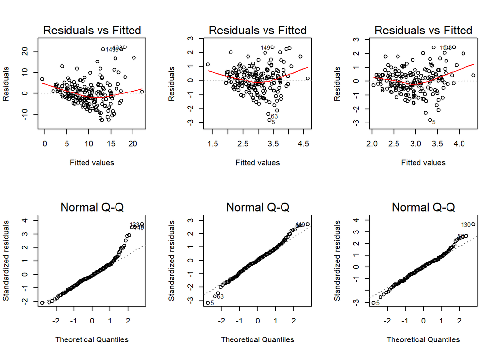

```r
par(mfrow=c(2,3))
plot(fit_1.3, 1)
plot(fit_1.5, 1)
plot(fit_1.6, 1)
plot(fit_1.3, 2)
plot(fit_1.5, 2)
plot(fit_1.6, 2)
```

# Evaluate estimats over time

```r
# fit_1.3 accross five year incraments form 2000 till 2015
DV = 'suicide_rate'
# IVs = c('spend', 'growth', 'netUsers', 'preprimary', 'secondary', 'primary',
#         'enrol', 'female', 'male', 'density', 'tourism', 'cell', 'air', 'pop',
#         'Unemployment', 'UnemployMale', 'UnemployFemale', 'GDP', 'dying', 'suicide_rate')
IVs = c('growth', 'netUsers', 'dying')

# edu_IVs = c('spend', 'preprimary', 'secondary', 'primary', 'enrol')

nested_fit_2 <- selfharm_nest %>%
  mutate(model = purrr::map(data, ~ z.getFit(dat = ., DV = DV, IVs = IVs)),
         results = purrr::map(model, ~ broom::tidy(x = ., conf.int = TRUE, conf.level = 0.95)),
         diagnostics = purrr::map(model, glance))

# nested_fit2$summary
# glance(stepResult)
# selfharm_nest$year
```

```r
# t <- nested_fit_2$results[[1]] %>%
#   rename('estimate.2015' = 'estimate') %>%
#   select(c(term, estimate.2015, p.value)) %>%
#   cbind(nested_fit_2$results[[2]] %>%
#           rename('estimate.2010' = 'estimate') %>%
#           select(c(estimate.2010, p.value))) %>%
#   cbind(nested_fit_2$results[[3]] %>%
#           rename('estimate.2005' = 'estimate') %>%
#           select(c(estimate.2005, p.value))) %>%
#   cbind(nested_fit_2$results[[4]] %>%
#           rename('estimate.2000' = 'estimate') %>%
#           select(c(estimate.2000, p.value))) %>%
#   mutate_if(is.numeric, ~ round(.,3))


# Compare Diagnostics
cbind(Model=sapply(1:4, function(x) as.character(nested_fit_2$year[x])),
      rbind(diagnostics_1,
            diagnostics_1.1,
            diagnostics_1.2,
            diagnostics_1.3)) %>%
  mutate_if(is.numeric, ~ round(.,3)) %>%
  mutate(df = paste(df,df.residual, sep = '/'),
         'AIC/BIC' = paste(round(AIC,1),round(BIC,1), sep='/')) %>%
  select(-c(r.squared, statistic, logLik, df.residual,AIC,BIC))
```

[output not shown]

```r
print('2000')
```

```
## [1] "2000"
```

```r
nested_fit_2$results[[1]] %>%
  select(term:p.value) %>%
  mutate_if(is.numeric,~ round(.,3))
```

```
## # A tibble: 4 x 5
##   term        estimate std.error statistic p.value
##   <chr>          <dbl>     <dbl>     <dbl>   <dbl>
## 1 (Intercept)    0.496     3.15      0.158   0.875
## 2 growth        -2.65      0.437    -6.06    0
## 3 netUsers       0.214     0.054     3.94    0
## 4 dying          0.561     0.115     4.88    0
```

```r
print('2005')
```

```
## [1] "2005"
```

```r
nested_fit_2$results[[2]] %>%
  select(term:p.value) %>%
  mutate_if(is.numeric,~ round(.,3))
```

```
## # A tibble: 4 x 5
##   term        estimate std.error statistic p.value
##   <chr>          <dbl>     <dbl>     <dbl>   <dbl>
## 1 (Intercept)   -2.29      2.74     -0.837   0.404
## 2 growth        -1.25      0.302    -4.14    0
## 3 netUsers       0.16      0.027     5.85    0
## 4 dying          0.528     0.102     5.19    0
```

```r
print('2010')
```

```
## [1] "2010"
```

```r
nested_fit_2$results[[3]] %>%
  select(term:p.value) %>%
  mutate_if(is.numeric,~ round(.,3))
```

```
## # A tibble: 4 x 5
##   term        estimate std.error statistic p.value
##   <chr>          <dbl>     <dbl>     <dbl>   <dbl>
## 1 (Intercept)   -1.39      2.71     -0.512   0.609
## 2 growth        -1.37      0.309    -4.43    0
## 3 netUsers       0.123     0.022     5.55    0
## 4 dying          0.47      0.099     4.72    0
```

```r
print('2015')
```

```
## [1] "2015"
```

```r
nested_fit_2$results[[4]] %>%
  select(term:p.value) %>%
  mutate_if(is.numeric,~ round(.,3))
```

```
## # A tibble: 4 x 5
##   term        estimate std.error statistic p.value
##   <chr>          <dbl>     <dbl>     <dbl>   <dbl>
## 1 (Intercept)    3.49      2.69       1.30   0.196
## 2 growth        -1.48      0.386     -3.83   0
## 3 netUsers       0.073     0.021      3.55   0
## 4 dying          0.243     0.092      2.64   0.009
```

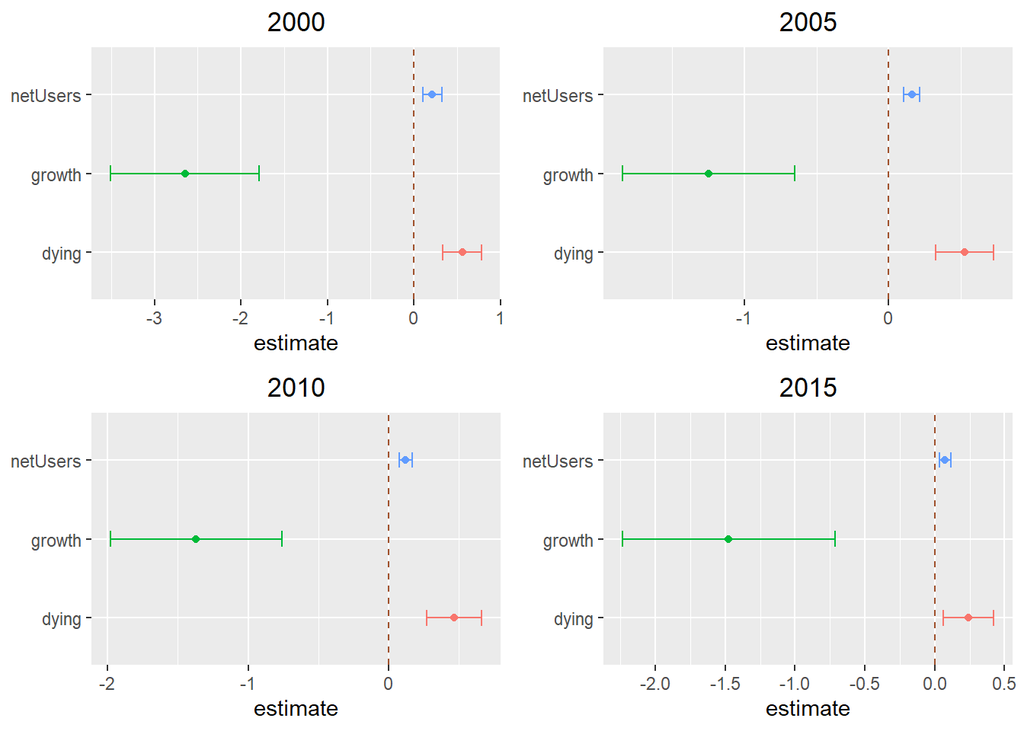

```r
grid.arrange(z.plotMargin_results(nested_fit_2$results[[1]],
                                  title = as.character(nested_fit_2$year[1][1])),
             z.plotMargin_results(nested_fit_2$results[[2]],
                                  title = as.character(nested_fit_2$year[2][1])),
             z.plotMargin_results(nested_fit_2$results[[3]],
                                  title = as.character(nested_fit_2$year[3][1])),
             z.plotMargin_results(nested_fit_2$results[[4]],
                                  title = as.character(nested_fit_2$year[4][1])))
```

```r
# nested stepwise fitting on all possable regressiors
DV = 'suicide_rate'
IVs = c('spend', 'growth', 'netUsers', 'preprimary', 'secondary', 'primary',
        'enrol', 'female', 'male', 'density', 'tourism', 'cell', 'air', 'pop',
        'Unemployment', 'UnemployMale', 'UnemployFemale', 'GDP', 'dying')

nested_fit_3 <- selfharm_nest %>%
  mutate(model = purrr::map(data, ~ z.step(dat = ., DV = DV, IVs = IVs)),
         results = purrr::map(model, ~ broom::tidy(x = ., conf.int = TRUE, conf.level = 0.95)),
         diagnostics = purrr::map(model, glance))
```

```
## Start:  AIC=194.7
## suicide_rate ~ 1
##
##                  Df Sum of Sq    RSS    AIC
## + growth          1    916.72 2594.9 183.39
## + UnemployMale    1    411.17 3100.5 191.22
## + dying           1    369.60 3142.0 191.81
## + netUsers        1    213.90 3297.7 193.94
## + Unemployment    1    164.19 3347.4 194.60
## <none>                        3511.6 194.70
## + preprimary      1    143.52 3368.1 194.87
## + GDP             1    105.43 3406.2 195.36
## + secondary       1    102.13 3409.5 195.41
## + cell            1     98.50 3413.1 195.45
## + spend           1     88.39 3423.2 195.58
## + air             1     54.34 3457.3 196.02
## + enrol           1     52.01 3459.6 196.05
## + female          1     49.19 3462.4 196.08
## + pop             1     46.94 3464.7 196.11
## + male            1     45.11 3466.5 196.14
## + tourism         1     41.28 3470.4 196.18
## + primary         1     26.42 3485.2 196.37
## + UnemployFemale  1      5.73 3505.9 196.63
## + density         1      1.80 3509.8 196.68
##
## Step:  AIC=183.39
## suicide_rate ~ growth
##
##                  Df Sum of Sq    RSS    AIC
## + dying           1   202.858 2392.1 181.81
## + tourism         1   147.828 2447.1 182.81
## <none>                        2594.9 183.39
## + preprimary      1   106.026 2488.9 183.56
## + female          1    83.078 2511.8 183.96
## + pop             1    81.766 2513.2 183.98
## + enrol           1    81.501 2513.4 183.99
## + male            1    80.791 2514.1 184.00
## + secondary       1    80.240 2514.7 184.01
## + UnemployMale    1    73.605 2521.3 184.13
## + netUsers        1    62.231 2532.7 184.32
```

[output cut: 675 more lines]

```
##
## Step:  AIC=43.1
## suicide_rate ~ growth + spend + dying + density + enrol + cell +
##     air
##
##              Df Sum of Sq    RSS    AIC
## <none>                    83.716 43.102
## + female      1    3.2684 80.448 44.425
## + primary     1    2.0220 81.694 44.686
## + pop         1    1.9705 81.746 44.697
## + preprimary  1    1.9426 81.774 44.703
## + male        1    1.5233 82.193 44.790
## + secondary   1    1.0883 82.628 44.879
## + netUsers    1    0.8634 82.853 44.926
## + GDP         1    0.3967 83.320 45.021
```

```r
#
# as.character(nested_fit_3$year[1])
#
# sapply(1:4, function(x) as.character(formula(nested_fit_3$model[[x]]))[3])
#
# as.character(nested_fit_3$diagnostics[[1]][c(2,11)])
# nested_fit_3$diagnostics[[1]][c(2,11)]
# round(nested_fit_3$diagnostics[[1]][c(2,11)],4)
```

```r
# results table to CSV
nested.fun <- tibble(fit = sapply(1:4, function(x) as.character(formula(nested_fit_3$model[[x]]))[3]),
                     adj_R2 = sapply(1:4, function(x) as.character(round(nested_fit_3$diagnostics[[x]][2],4))),
                     df.resid = sapply(1:4, function(x) as.character(nested_fit_3$diagnostics[[x]][11])),
                     year = sapply(1:4, function(x) as.character(nested_fit_3$year[x])))

nested.fun
```

```
## # A tibble: 4 x 4
##   fit                                                 adj_R2 df.resid year
##   <chr>                                               <chr>  <chr>    <chr>
## 1 growth + dying + netUsers + tourism + preprimary +~ 0.5477 34       2000
## 2 growth + cell + density + dying + netUsers + prima~ 0.4751 39       2005
## 3 growth + UnemployMale + Unemployment + cell + spen~ 0.6486 42       2010
## 4 growth + spend + dying + density + enrol + cell + ~ 0.697  9        2015
```

```r
# write_csv(nested.fun, paste0(fpath, "nestedFUN.csv"))
```

# WHO’s 2016 plublshed graphs

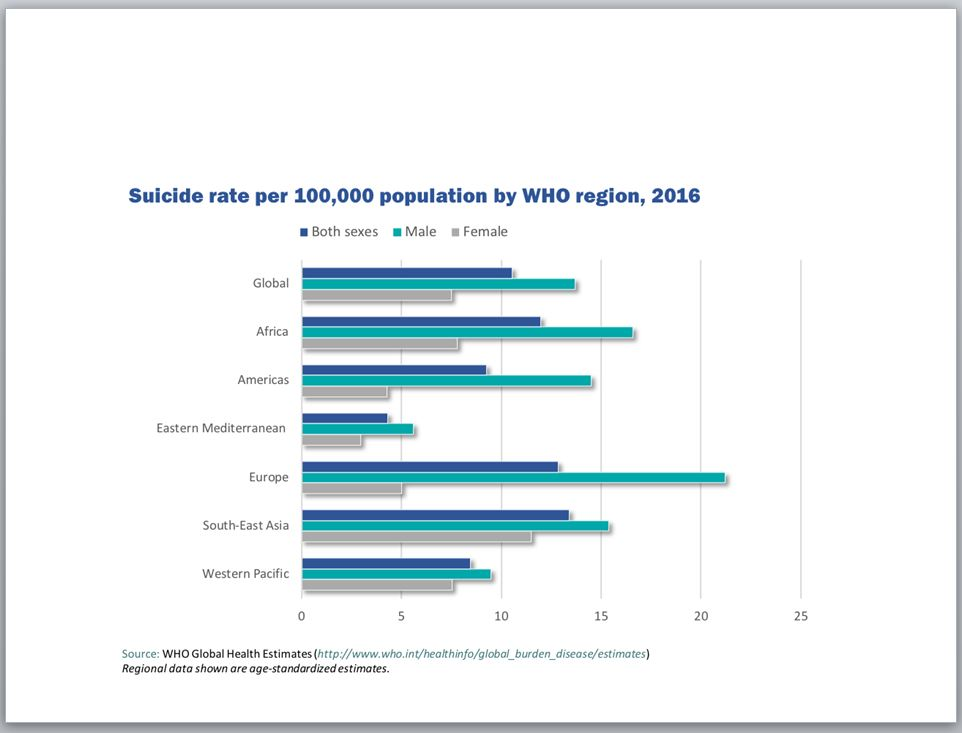

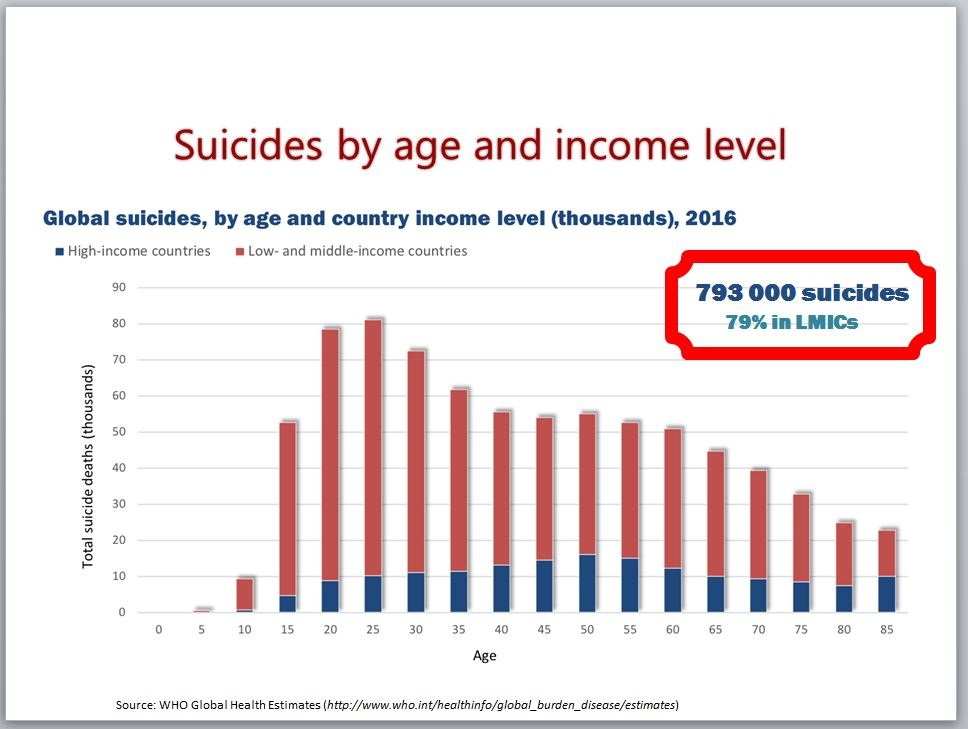

# Count

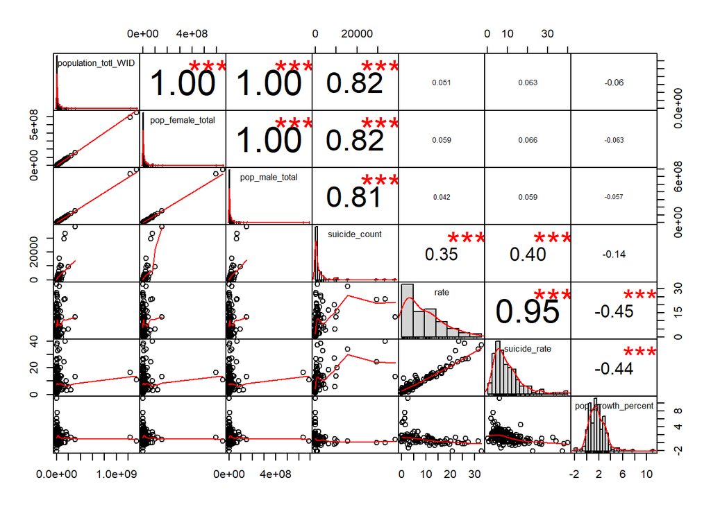

```r
# selfharm_dat %>%
#   filter(year==2010,
#          suicide_count < 10000,
#          population_totl_WID < 5e7) %>%
#   ggplot(aes(x=population_totl_WID,y=suicide_count)) +
#   geom_point()
#
# selfharm_dat %>%
#   filter(year==2010) %>%
#   mutate(rate = (suicide_count/population_totl_WID)*100000) %>%
#   ggplot(aes(x=rate,y=suicide_rate)) +
#   geom_point()
#
# selfharm_dat %>%
#   filter(year==2010) %>%
#   mutate(rate = (suicide_count/population_totl_WID)*100000) %>%
#   ggplot(aes(x=rate,y=suicide_per100k)) +
#   geom_point()
#
# selfharm_dat %>%
#   filter(year==2010) %>%
#   mutate(rate = (suicide_count/population_totl_WID)*100000) %>%
#   ggplot(aes(x=suicide_rate,y=suicide_per100k)) +
#   geom_point()
#
# selfharm_dat %>%
#   filter(year==2010) %>%
#   mutate(rate = (suicide_count/population_totl_WID)*100000) %>%
#   ggplot(aes(x=population_total_edu,y=population_totl_WID)) +
#   geom_point()
#
# selfharm_dat %>%
#   filter(year==2010) %>%
#   mutate(rate = (suicide_count/population_totl_WID)*100000) %>%
#   ggplot(aes(x=population_totl_WID,y=suicide_count)) +
#   geom_point(alpha=0.15) +
#   geom_point(aes(y=suicide_rate),color='green',alpha=0.5) +
#   geom_point(aes(y=rate),color='blue')
#
# selfharm_dat %>%
#   filter(year==2010,
#          suicide_count < 10000,
#          population_totl_WID < 5e7) %>%
#   mutate(rate = (suicide_count/population_totl_WID)*100000) %>%
#   ggplot(aes(x=population_totl_WID,y=suicide_count)) +
#   geom_point(alpha=0.15) +
#   geom_point(aes(y=suicide_rate),color='green',alpha=0.5) +
#   geom_point(aes(y=rate),color='blue')
#
# selfharm_dat %>%
#   filter(year==2010) %>%
#   mutate(rate = (suicide_count/population_totl_WID)*100000) %>%
#   ggplot(aes(x=suicide_rate,y=suicide_count)) +
#   geom_point()

selfharm_dat %>%
  filter(year==2010) %>%
  mutate(rate = (suicide_count/population_totl_WID)*100000) %>%
  select(c(population_totl_WID, pop_female_total, pop_male_total,
           suicide_count, rate, suicide_rate, pop_growth_percent)) %>%
  chart.Correlation(., histogram=TRUE, method = "pearson")
```

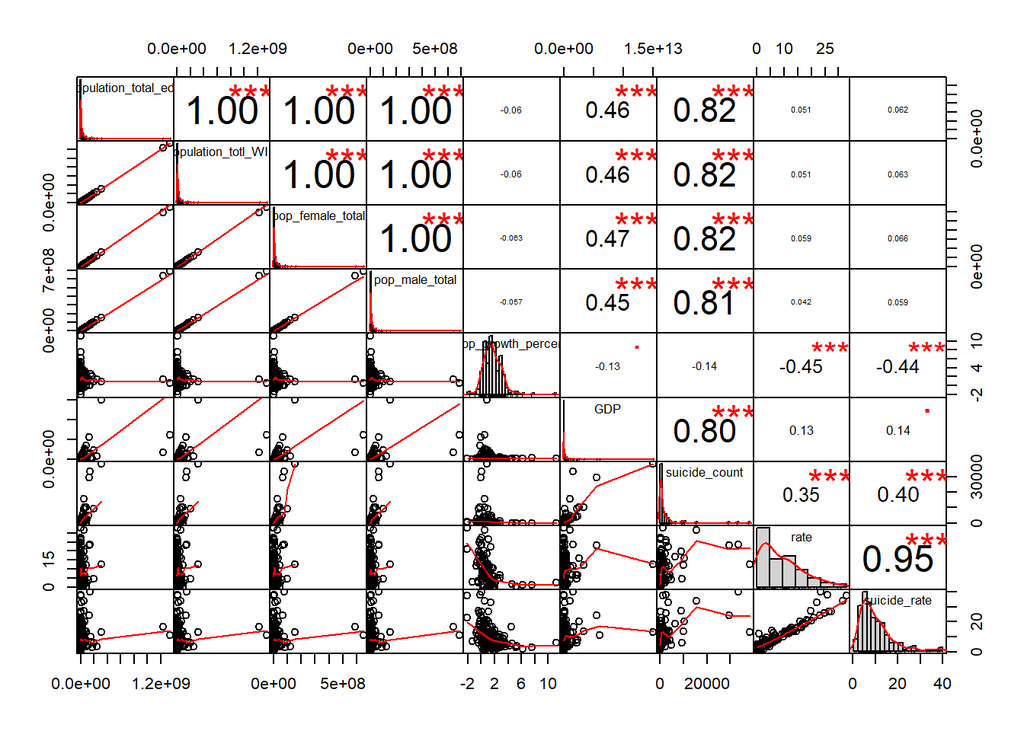

```r
selfharm_dat %>%
  filter(year==2010) %>%
  mutate(rate = (suicide_count/population_totl_WID)*100000) %>%
  select(c(population_total_edu,population_totl_WID, pop_female_total, pop_male_total,
           pop_growth_percent, GDP, suicide_count, rate, suicide_rate)) %>%
  chart.Correlation(., histogram=TRUE, method = "pearson")
```

```r
# Nested data by year with abreveated names
count_nest <- selfharm_dat  %>%
  select(-c(population_total_edu, suicide_per100k,
            suicide_ageadj, suicide_rate, precipitation)) %>%
  mutate(selfharm_rate = (suicide_count/population_totl_WID)*100000) %>%
  rename(pop = population_totl_WID, spend = edu_spend_percent, growth = pop_growth_percent,
         netUsers = internet_user_per100, preprimary = teachers_preprimary,
         secondary = teachers_secondary, primary = teachers_primary,
         enrol = enrolment_secondary, female = pop_female_total, male = pop_male_total,
         density = pop_density,  cell = cellular_per100, air = air_transport,
         Unemployment = Unemployment_percent_laborforce, UnemployMale = Unemployment_percent_male,
         UnemployFemale = Unemployment_percent_female, dying = Probability_30to70_dying) %>%
  filter(!is.na(suicide_count)) %>%
  group_by(year) %>%
  nest()

# summary(selfharm_nest$data[[2]])
# selfharm_nest$year
```

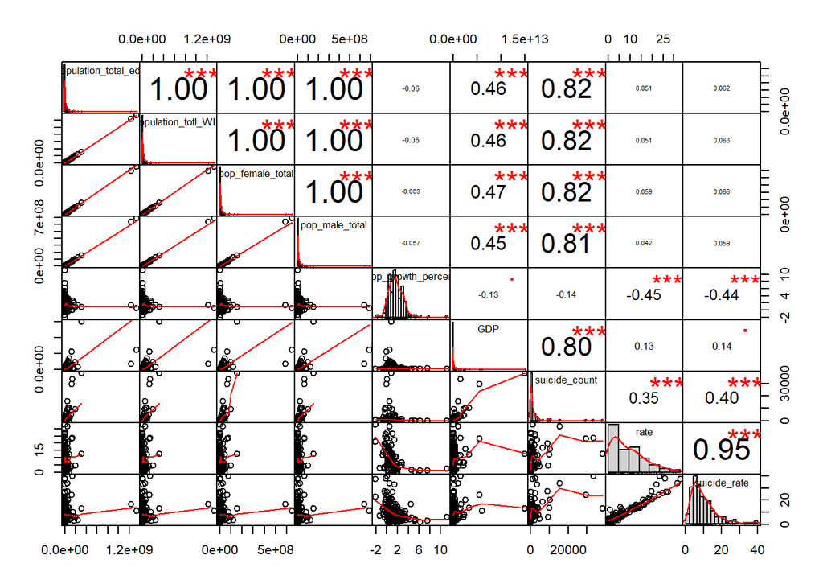

```r
selfharm_dat %>%
  filter(year==2010) %>%
  mutate(rate = (suicide_count/population_totl_WID)*100000) %>%
  select(c(population_total_edu,population_totl_WID, pop_female_total, pop_male_total,
           pop_growth_percent, GDP, suicide_count, rate, suicide_rate)) %>%
  chart.Correlation(., histogram=TRUE, method = "pearson")
```

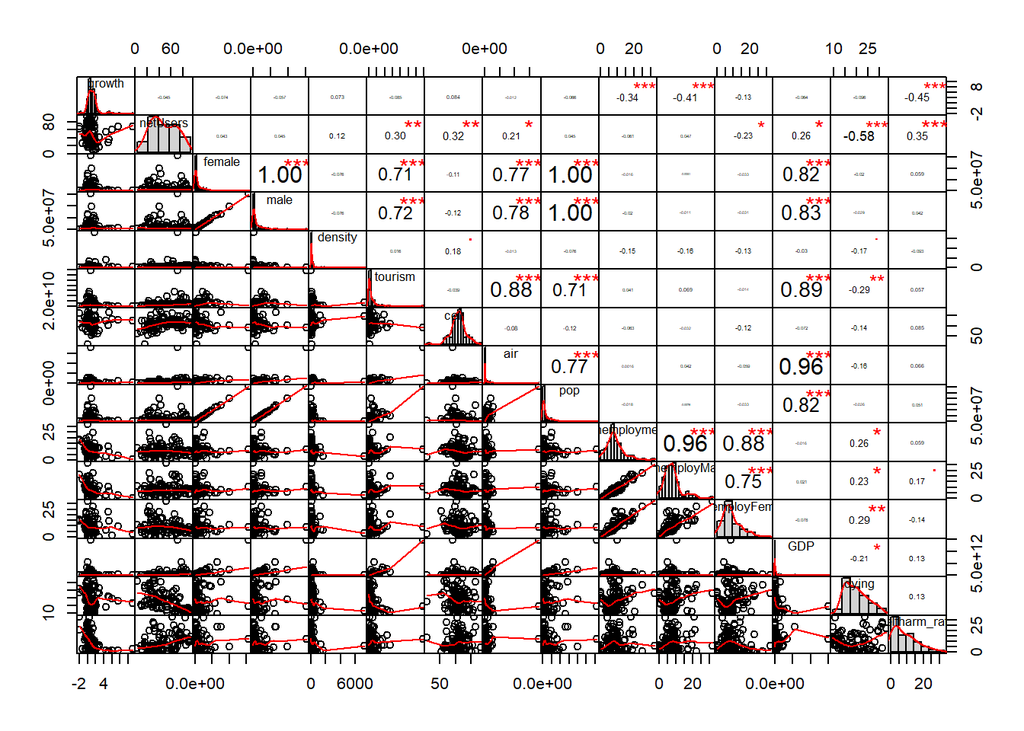

```r
count_nest$data[[3]] %>%
  select(c('growth', 'netUsers', 'female', 'male', 'density', 'tourism', 'cell', 'air', 'pop',
        'Unemployment', 'UnemployMale', 'UnemployFemale', 'GDP', 'dying', 'selfharm_rate')) %>%
  chart.Correlation(., histogram=TRUE, method = "pearson")
```

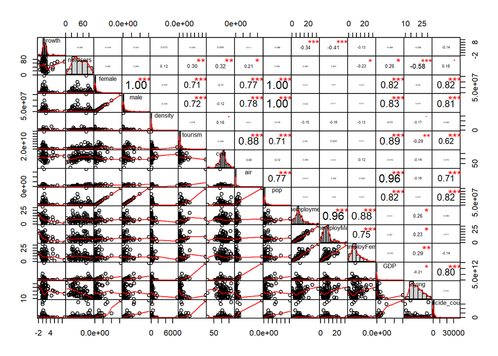

```r
count_nest$data[[3]] %>%
  select(c('growth', 'netUsers', 'female', 'male', 'density', 'tourism', 'cell', 'air', 'pop',
        'Unemployment', 'UnemployMale', 'UnemployFemale', 'GDP', 'dying', 'suicide_count')) %>%
  chart.Correlation(., histogram=TRUE, method = "pearson")
```

```r
# Nested stepwise model fitting
DV = 'selfharm_rate'
# IVs = c('spend', 'growth', 'netUsers', 'preprimary', 'secondary', 'primary',
#         'enrol', 'female', 'male', 'density', 'tourism', 'cell', 'air', 'pop',
#         'Unemployment', 'UnemployMale', 'UnemployFemale', 'GDP', 'dying', 'suicide_rate')
IVs = c('growth', 'netUsers', 'female', 'male', 'density', 'tourism', 'cell', 'air', 'pop',
        'Unemployment', 'UnemployMale', 'UnemployFemale', 'GDP', 'dying')

# edu_IVs = c('spend', 'preprimary', 'secondary', 'primary', 'enrol')

nestedFit_countRate <- count_nest %>%
  mutate(model = purrr::map(data, ~ z.step(dat = ., DV = DV, IVs = IVs)),
         results = purrr::map(model, ~ broom::tidy(x = ., conf.int = TRUE, conf.level = 0.95)),
         diagnostics = purrr::map(model, glance))
```

```
## Start:  AIC=431.2
## selfharm_rate ~ 1
##
##                  Df Sum of Sq    RSS    AIC
## + growth          1   3085.90 5953.0 393.95
## + dying           1    375.01 8663.9 429.22
## + netUsers        1    340.22 8698.7 429.60
## + cell            1    293.72 8745.2 430.10
## + UnemployMale    1    258.15 8780.8 430.48
## <none>                        9038.9 431.20
## + UnemployFemale  1     71.22 8967.7 432.46
## + female          1     46.88 8992.0 432.72
## + density         1     46.05 8992.9 432.72
## + pop             1     36.40 9002.5 432.82
## + Unemployment    1     34.23 9004.7 432.85
## + GDP             1     30.52 9008.4 432.89
## + male            1     26.08 9012.8 432.93
## + air             1      3.49 9035.4 433.17
## + tourism         1      0.92 9038.0 433.19
##
## Step:  AIC=393.95
## selfharm_rate ~ growth
##
##                  Df Sum of Sq    RSS    AIC
## + UnemployFemale  1   259.268 5693.8 391.76
## + netUsers        1   211.160 5741.9 392.55
## + cell            1   188.698 5764.3 392.92
## + Unemployment    1   141.044 5812.0 393.69
## <none>                        5953.0 393.95
## + dying           1   102.381 5850.6 394.32
## + UnemployMale    1    32.728 5920.3 395.43
## + female          1    19.533 5933.5 395.64
## + pop             1    15.679 5937.3 395.70
## + male            1    11.811 5941.2 395.76
## + GDP             1    11.212 5941.8 395.77
## + tourism         1     3.824 5949.2 395.89
## + air             1     2.973 5950.1 395.90
## + density         1     0.267 5952.8 395.94
##
## Step:  AIC=391.76
```

[output cut: 269 more lines]

```
## + pop      1     0.059 1609.5 218.81
## + male     1     0.021 1609.6 218.81
##
## Step:  AIC=216.48
## selfharm_rate ~ growth + netUsers + dying
##
##           Df Sum of Sq    RSS    AIC
## <none>                 1553.8 216.48
## + density  1   16.1041 1537.7 217.79
## + GDP      1    7.9211 1545.9 218.14
## + cell     1    7.4997 1546.3 218.16
## + air      1    5.8425 1547.9 218.23
## + female   1    0.5216 1553.3 218.46
## + pop      1    0.3967 1553.4 218.46
## + male     1    0.3212 1553.5 218.47
```

```r
# as.character(formula(z.getFit(count_nest$data[[3]], DV,IVs)))
```

```r
sapply(1:4, function(x) as.character(formula(nestedFit_countRate$model[[x]]))[3])
```

```
## [1] "growth + UnemployFemale + dying + cell"
## [2] "growth + cell + dying + netUsers"
## [3] "growth + netUsers + dying + UnemployFemale"
## [4] "growth + netUsers + dying"
```

```r
# Compare Diagnostics
cbind(Model=as.character(nestedFit_countRate$year),
      rbind(nestedFit_countRate$diagnostics[[1]],
            nestedFit_countRate$diagnostics[[2]],
            nestedFit_countRate$diagnostics[[3]],
            nestedFit_countRate$diagnostics[[4]])) %>%
  mutate(df = paste(df,df.residual, sep = '/'),
         'AIC/BIC' = paste(round(AIC,1),round(BIC,1), sep='/')) %>%
  select(-c(r.squared, statistic, logLik, df.residual,AIC,BIC))
```

```
##   Model adj.r.squared    sigma      p.value   df deviance     AIC/BIC
## 1  2000     0.4354260 7.407597 2.713394e-11 5/89 4883.653 650.1/665.4
## 2  2005     0.4090715 6.266280 4.186997e-10 5/86 3376.898 599.1/614.2
## 3  2010     0.4525532 5.859469 2.218000e-12 5/93 3193.004   631.5/647
## 4  2015     0.4284057 5.006101 2.976543e-08 4/62 1553.785 405.8/416.7
```

```r
# Nested stepwise model fitting
DV = 'suicide_count'
# IVs = c('spend', 'growth', 'netUsers', 'preprimary', 'secondary', 'primary',
#         'enrol', 'female', 'male', 'density', 'tourism', 'cell', 'air', 'pop',
#         'Unemployment', 'UnemployMale', 'UnemployFemale', 'GDP', 'dying', 'suicide_rate')
IVs = c('growth', 'netUsers', 'female', 'male', 'density', 'tourism', 'cell', 'air', 'pop',
        'Unemployment', 'UnemployMale', 'UnemployFemale', 'GDP', 'dying')

# edu_IVs = c('spend', 'preprimary', 'secondary', 'primary', 'enrol')

nestedFit_counts1 <- count_nest %>%
  mutate(model = purrr::map(data, ~ z.step(dat = ., DV = DV, IVs = IVs)),
         results = purrr::map(model, ~ broom::tidy(x = ., conf.int = TRUE, conf.level = 0.95)),
         diagnostics = purrr::map(model, glance))
```

```
## Start:  AIC=1676.46
## suicide_count ~ 1
##
##                  Df  Sum of Sq        RSS    AIC
## + female          1 2795404582 2326009021 1604.3
## + pop             1 2706766763 2414646840 1607.8
## + male            1 2613312220 2508101383 1611.3
## + GDP             1 1540239954 3581173649 1644.8
## + air             1 1129458949 3991954654 1655.0
## + tourism         1  861193503 4260220100 1661.2
## + growth          1  241627387 4879786216 1673.9
## <none>                         5121413603 1676.5
## + dying           1   67563102 5053850501 1677.2
## + netUsers        1   55655617 5065757986 1677.4
## + UnemployFemale  1   30169645 5091243957 1677.9
## + density         1   11922030 5109491573 1678.2
## + cell            1    4154222 5117259381 1678.4
## + Unemployment    1    3568808 5117844795 1678.4
## + UnemployMale    1     529685 5120883918 1678.5
##
## Step:  AIC=1604.27
## suicide_count ~ female
##
##                  Df  Sum of Sq        RSS    AIC
## + male            1 1768260782  557748238 1472.0
## + pop             1 1669187268  656821753 1487.4
## + growth          1  175372864 2150636156 1598.9
## + tourism         1  106838657 2219170364 1601.8
## + dying           1   91682817 2234326204 1602.5
## + air             1   69005090 2257003931 1603.4
## <none>                         2326009021 1604.3
## + UnemployFemale  1   15586574 2310422447 1605.6
## + GDP             1   10349403 2315659617 1605.8
## + UnemployMale    1    4037408 2321971613 1606.1
## + netUsers        1     487654 2325521367 1606.2
## + density         1     311356 2325697665 1606.3
## + Unemployment    1      89484 2325919536 1606.3
## + cell            1      20393 2325988628 1606.3
##
## Step:  AIC=1472.04
```

[output cut: 456 more lines]

```
## <none>                 208150545  999.63
## + cell     1   3925417 204225128 1000.38
## + growth   1   1371681 206778865 1001.20
## + dying    1    205898 207944647 1001.57
## + density  1     54739 208095807 1001.61
##
## Step:  AIC=999.02
## suicide_count ~ female + GDP + pop + netUsers + air + male
##
##           Df Sum of Sq       RSS     AIC
## <none>                 200082951  999.02
## + cell     1   4313535 195769416  999.58
## + growth   1    362656 199720295 1000.90
## + dying    1    103844 199979107 1000.99
## + density  1     87967 199994983 1000.99
```

```r
sapply(1:4, function(x) as.character(formula(nestedFit_counts1$model[[x]]))[3])
```

```
## [1] "female + male + GDP + tourism + air + UnemployMale + pop"
## [2] "female + pop + GDP + air + tourism + UnemployFemale + growth + male + netUsers"
## [3] "female + pop + GDP + tourism + netUsers + air + Unemployment"
## [4] "female + GDP + pop + netUsers + air + male"
```